# Full analyses of regression between diversity stats and environmental variables

Ivan Scotti, ivan.scotti@inra.fr

12/9/2020

# 1. Preparation work

Review of the material at hand:

- **all_results_stairwayplot.tsv**: output of stairway plot analyses
- **gtree_allspecies_env_dataset_extra_samples_20200908.csv**: all geographical and environmental variables from GenTree fieldwork. *For the purposes of the current analysis, environmental data will not be used - only geographical coordinates are included.*.

Notice that field data are published here: Opgenoorth L et al. (2021). The GenTree-Platform: linking phenotypes, tree-level environmental data, and genotypes in twelve major European forest tree species. *GigaScience*, in press.

- **construct** folder and files therein: admixture values for all K values for all species. *The relevant K for each species is detailed below (as drawn from Table S6 in the paper)*. Exact files to get data from for each species are detailed below.
- **Pi_estimates_vcf5.3.1** folder, **pi_CIs_1000replicates_allspecies.txt**: all pi statistics for all populations, both “raw” and from bootstraps.

The way forward should include at least:

- filling missing data when possible
- centering/standardising the variables (use scale())
- merging all data sets
- running full models
- running models with significant variables only
- recording slopes and finding a way to compare them

Start from data as recorded in ‘gtree_allspecies_env_dataset_extra_samples_20200908.csv’

## creating a full and clean data set

```r
sourceEnvData.df <- read.csv(file = "gtree_allspecies_env_dataset_extra_samples_20200908.csv", header = T)
#these are individual-level data (mostly)
#obtaining the means:
envDataMeans.df <- data.frame(apply(X = sourceEnvData.df[c(6:9,11:99)], FUN = bioMeanBy, y = sourceEnvData.df[,5], MARGIN = 2))
#adding species names:
speciesInEnvDataMeans <- matrix(unlist(strsplit(row.names(envDataMeans.df), split = "_")),ncol = 3, byrow = T)[,2]
envDataMeans.df <-cbind(speciesInEnvDataMeans, envDataMeans.df)
names(envDataMeans.df)[1] <- "species"
#cleaning tmp files:
rm(speciesInEnvDataMeans)
```

## an overview of variable distributions

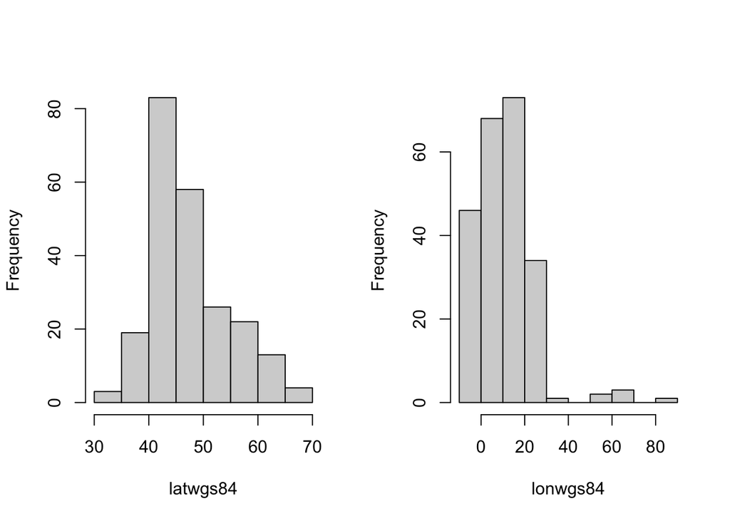

```r
# par(mfrow=c(3,3))
## not used for this study: distribution of all variables
# for (i in 2:93) hist(envDataMeans.df[,i], xlab=names(envDataMeans.df)[i], main="")
# inspection of geo variables only:
par(mfrow=c(1,2))
for (i in 2:3) hist(envDataMeans.df[,i], xlab=names(envDataMeans.df)[i], main="")
```

```r
## not used:
# for (i in 11:19) hist(envDataMeans.df[,i], xlab=names(envDataMeans.df)[i], main="")
```

##scaling the variables

```r
tmp <- apply(X = envDataMeans.df[2:94], FUN = scaleBy, y = envDataMeans.df[,1], MARGIN = 2)
## NOT working:
#envDataMeans.scaled.df <- data.frame(apply(X = envDataMeans.df[2:93], FUN = scaleBy, y = envDataMeans.df[,1], MARGIN = 2))
```

## some checks are needed: is the order of populations within species maintained?

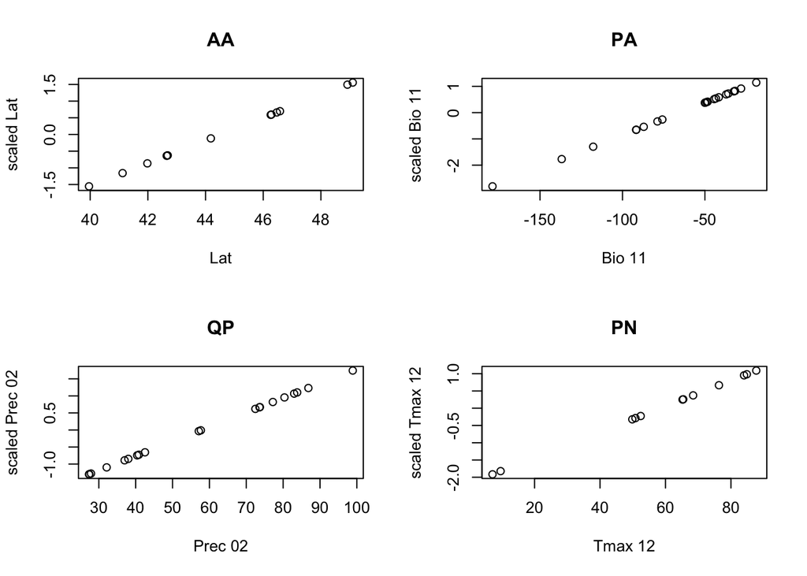

```r
# random pick of variables and species:
par(mfrow=c(2,2))
plot(x = subset(envDataMeans.df, species == "AA")$latwgs84, y = tmp$latwgs84$AA[,1], xlab = "Lat", ylab = "scaled Lat", main = "AA")
plot(x = subset(envDataMeans.df, species == "PA")$bio11, y = tmp$bio11$PA[,1], xlab = "Bio 11", ylab = "scaled Bio 11", main = "PA")
plot(x = subset(envDataMeans.df, species == "QP")$prec02, y = tmp$prec02$QP[,1], xlab = "Prec 02", ylab = "scaled Prec 02", main = "QP")
plot(x = subset(envDataMeans.df, species == "PN")$tmax12, y = tmp$tmax12$PN[,1], xlab = "Tmax 12", ylab = "scaled Tmax 12", main = "PN")
```

```r
#everything seems to be fine
#but population names must be repositioned in front of values
```

## reassembling a table

```r
## NOT USED: test: attempt one
# do.call(what = c, args = tmp$latwgs84) #oh, WOW.
#
# nesting do.call() within lapply():
tmp2 <- lapply(X = tmp, FUN = function(x) do.call(what = c, args = x))
# using do.call to fold the list into data.frame:
envDataMeans.scaled.df <- data.frame(do.call(what = cbind, args = tmp2))
#re-inserting species names in the table
speciesInEnvDataMeansScaled <- unlist(by(data = envDataMeans.df,
                                         INDICES = envDataMeans.df$species, FUN = function(x) x$species))
envDataMeans.scaled.df <- cbind(speciesInEnvDataMeansScaled, envDataMeans.scaled.df)
names(envDataMeans.scaled.df)[1] <- "species"
#getting reordered population names from envDataMeans.df
row.names(envDataMeans.scaled.df) <- unlist(by(data = envDataMeans.df, INDICES = envDataMeans.df$species, FUN = row.names))
#removing intemediate objects
rm(list=c("tmp","tmp2"))
#cleaning tmp files:
rm(speciesInEnvDataMeansScaled)
```

## scaling and centering diversity statistics:

### 1. stairway plot historical demography statistics:

```r
system("gzip -dk  all_results_stairwayplot.tsv.gz")
data.dt <- fread("all_results_stairwayplot.tsv", header = T, nrows = 1231558) # the second part of the file has single-pop data
system("rm  all_results_stairwayplot.tsv")
```

Computing smoothed curve and derivatives As a guidance, I used https://stackoverflow.com/questions/43615469/how-to-calculate-the-slope-of-a-smoothed-curve-in-r

```r
## NOT USED:
# #using birch and CH pop 5 as test data set
# tmp.dt <- subset(data.dt, species == "Bpendula" & pop == "CH_BP_05")
# #there are duplicated x values, keep only one of each
# tmp.dt <- tmp.dt[ which(!duplicated(tmp.dt$year)),]
# tmp_smoothed.curve <- smooth.Pspline(x = tmp.dt$year,
#                                      y = tmp.dt$Ne_median,
#                                      df = 20,
#                                      spar = 20,
#                                      method = 2)
# tmp.f1 <- predict(tmp_smoothed.curve, x = tmp.dt$year, nderiv=1)
# tmp.f2 <- predict(tmp_smoothed.curve, x = tmp.dt$year, nderiv=2)
```

```r
derivatives.sumstats <- by(data = data.dt, INDICES = data.dt$pop, FUN = derivatives, simplify = F)
derivatives.sumstats.df <- data.frame(do.call(what = rbind, args = derivatives.sumstats))
write.table(file = "derivatives_sumstats.txt", x = derivatives.sumstats.df, sep = "\t", quote = F)
```

adding mean, median, and sd of theta

```r
theta_means <- by(data = data.dt, INDICES = data.dt$pop, FUN = function(x) mean(x$theta_per_site_median), simplify = F)
theta_medians <- by(data = data.dt, INDICES = data.dt$pop, FUN = function(x) median(x$theta_per_site_median), simplify = F)
theta_sd <- by(data = data.dt, INDICES = data.dt$pop, FUN = function(x) sd(x$theta_per_site_median), simplify = F)
theta_stats.df <- do.call(what = data.frame, args = list(unlist(theta_means), unlist(theta_medians), unlist(theta_sd)))
names(theta_stats.df) <- c("mean_medianTheta", "median_medianTheta", "sd_medianTheta")
all.sumstats.df <- merge(by = 0, theta_stats.df, derivatives.sumstats.df)
row.names(all.sumstats.df) <- all.sumstats.df[,1]
all.sumstats.df <- all.sumstats.df[,-1]
#adding species names:
speciesInTheta <- matrix(unlist(strsplit(row.names(all.sumstats.df), split = "_")),ncol = 3, byrow = T)[,2]
all.sumstats.df <-cbind(speciesInTheta, all.sumstats.df)
names(all.sumstats.df)[1] <- "species"
#removing intermediate objects
rm(speciesInTheta)
```

Actual scaling and centering

```r
tmp.theta <- apply(X = all.sumstats.df[2:10], FUN = scaleBy, y = all.sumstats.df[,1], MARGIN = 2)
```

reassembling a table

```r
## NOT USED:
# attempt one - testing
# do.call(what = c, args = tmp$latwgs84) #oh, WOW.
# nesting do.call() within lapply():
tmp2.theta <- lapply(X = tmp.theta, FUN = function(x) do.call(what = c, args = x))
# using do.call to fold the list into data.frame:
all.sumstats.scaled.df <- data.frame(do.call(what = cbind, args = tmp2.theta))
#getting reordered population names from envDataMeans.df
row.names(all.sumstats.scaled.df) <- unlist(by(data = all.sumstats.df, INDICES = all.sumstats.df$species, FUN = row.names))
#removing intermedaite objects
rm(list=c("tmp.theta","tmp2.theta"))
```

### 2. pi values

Importing pi stats

```r
# from bootstrap values: keeping only the central values
piStats_boot.df <- read.table("pi_CIs_1000replicates_allspecies.txt", header = T)[,c(1:3,seq(4,20,4))]
# from "empirical" values:
#   for 0.2 missing values:
#    getting file name list
system(command = "ls Pi_estimates_vcf5.3.1/*0.2miss.txt > allSp_pi_per_pop0.2miss.filelist")
filelist <- readLines("allSp_pi_per_pop0.2miss.filelist")
#   importing tables
for (i in filelist) assign(x = i, value = read.table(i, header = T))
#   concatenating tables
allSp_pi_per_pop0.2miss.df <- do.call(what = rbind, args = lapply(ls(pattern="0.2miss"), get))
#   removing the "all plots" rows
allSp_pi_per_pop0.2miss.df <- allSp_pi_per_pop0.2miss.df[allSp_pi_per_pop0.2miss.df$pop!="all_pops",]
#     rearranging with pivot_larger: complete data
allSp_pi_per_pop0.2miss_pi_complete.df <- allSp_pi_per_pop0.2miss.df[1:3] %>%
  pivot_wider(id_cols = 1, names_from = site.type, values_from = pi_complete_data)
#       renaming columns
names(allSp_pi_per_pop0.2miss_pi_complete.df)[2:7] <-paste0(names(allSp_pi_per_pop0.2miss_pi_complete.df)[2:7],"_complete_0.2miss")
#     rearranging with pivot_larger: best orthologs
allSp_pi_per_pop0.2miss_pi_bestOrtho.df <- allSp_pi_per_pop0.2miss.df[c(1,2,4)] %>%
  pivot_wider(id_cols = 1, names_from = site.type, values_from = pi_best_ortho)
#       renaming columns
names(allSp_pi_per_pop0.2miss_pi_bestOrtho.df)[2:7] <-paste0(names(allSp_pi_per_pop0.2miss_pi_bestOrtho.df)[2:7],"_bestOrtho_0.2miss")
#     rearranging with pivot_larger: candidates
allSp_pi_per_pop0.2miss_pi_candidates.df <- allSp_pi_per_pop0.2miss.df[c(1,2,5)] %>%
  pivot_wider(id_cols = 1, names_from = site.type, values_from = pi_candidate)
#       renaming columns
names(allSp_pi_per_pop0.2miss_pi_candidates.df)[2:7] <-paste0(names(allSp_pi_per_pop0.2miss_pi_candidates.df)[2:7],"_candidate_0.2miss")
#    merging all tables
allSp_pi_per_pop0.2miss_pi.df <- Reduce(merge, list(allSp_pi_per_pop0.2miss_pi_complete.df,
                                                        allSp_pi_per_pop0.2miss_pi_bestOrtho.df,
                                                        allSp_pi_per_pop0.2miss_pi_candidates.df))
#   removing intermediate files
rm(list=c("allSp_pi_per_pop0.2miss.df",
        "allSp_pi_per_pop0.2miss_pi_complete.df",
        "allSp_pi_per_pop0.2miss_pi_bestOrtho.df",
        "allSp_pi_per_pop0.2miss_pi_candidates.df"))
rm(list=ls(pattern = "0.2miss.txt"))
#
#
#   for 0.5 missing values:
#    getting file name list
system(command = "ls Pi_estimates_vcf5.3.1/*0.5miss.txt > allSp_pi_per_pop0.5miss.filelist")
filelist <- readLines("allSp_pi_per_pop0.5miss.filelist")
#   importing tables
for (i in filelist) assign(x = i, value = read.table(i, header = T))
#   concatenating tables
allSp_pi_per_pop0.5miss.df <- do.call(what = rbind, args = lapply(ls(pattern="0.5miss"), get))
#   removing the "all plots" rows
allSp_pi_per_pop0.5miss.df <- allSp_pi_per_pop0.5miss.df[allSp_pi_per_pop0.5miss.df$pop!="all_pops",]
#     rearranging with pivot_larger: complete data
allSp_pi_per_pop0.5miss_pi_complete.df <- allSp_pi_per_pop0.5miss.df[1:3] %>%
  pivot_wider(id_cols = 1, names_from = site.type, values_from = pi_complete_data)
#       renaming columns
names(allSp_pi_per_pop0.5miss_pi_complete.df)[2:7] <-paste0(names(allSp_pi_per_pop0.5miss_pi_complete.df)[2:7],"_complete_0.5miss")
#     rearranging with pivot_larger: best orthologs
allSp_pi_per_pop0.5miss_pi_bestOrtho.df <- allSp_pi_per_pop0.5miss.df[c(1,2,4)] %>%
  pivot_wider(id_cols = 1, names_from = site.type, values_from = pi_best_ortho)
#       renaming columns
names(allSp_pi_per_pop0.5miss_pi_bestOrtho.df)[2:7] <-paste0(names(allSp_pi_per_pop0.5miss_pi_bestOrtho.df)[2:7],"_bestOrtho_0.5miss")
#     rearranging with pivot_larger: candidates
allSp_pi_per_pop0.5miss_pi_candidates.df <- allSp_pi_per_pop0.5miss.df[c(1,2,5)] %>%
  pivot_wider(id_cols = 1, names_from = site.type, values_from = pi_candidate)
#       renaming columns
names(allSp_pi_per_pop0.5miss_pi_candidates.df)[2:7] <-paste0(names(allSp_pi_per_pop0.5miss_pi_candidates.df)[2:7],"_candidate_0.5miss")
#    merging all tables
allSp_pi_per_pop0.5miss_pi.df <- Reduce(merge, list(allSp_pi_per_pop0.5miss_pi_complete.df,
                                                        allSp_pi_per_pop0.5miss_pi_bestOrtho.df,
                                                        allSp_pi_per_pop0.5miss_pi_candidates.df))
#   removing intermediate files
rm(list=c("allSp_pi_per_pop0.5miss.df",
        "allSp_pi_per_pop0.5miss_pi_complete.df",
        "allSp_pi_per_pop0.5miss_pi_bestOrtho.df",
        "allSp_pi_per_pop0.5miss_pi_candidates.df"))
rm(list=ls(pattern = "0.5miss.txt"))
#
#
#
# merging 0.5miss and 0.2miss tables
allSp_pi_per_pop0.5_0.2miss_pi.df <- merge(allSp_pi_per_pop0.5miss_pi.df,allSp_pi_per_pop0.2miss_pi.df)
# merging empirical and bootstrap data
piStats.df <- merge(piStats_boot.df, allSp_pi_per_pop0.5_0.2miss_pi.df)
row.names(piStats.df) <- piStats.df$pop
# removing intermediate files
rm(list=c("allSp_pi_per_pop0.5miss_pi.df","allSp_pi_per_pop0.2miss_pi.df","piStats_boot.df","allSp_pi_per_pop0.5_0.2miss_pi.df"))
rm(filelist)
```

Actual scaling and centering

```r
tmp.pi <- apply(X = piStats.df[4:44], FUN = scaleBy, y = piStats.df[,3], MARGIN = 2)
```

reassembling a table

```r
#attempt one
# do.call(what = c, args = tmp$latwgs84) #oh, WOW.
# nesting do.call() within lapply():
tmp2.pi <- lapply(X = tmp.pi, FUN = function(x) do.call(what = c, args = x))
# using do.call to fold the list into data.frame:
piStats.scaled.df <- data.frame(do.call(what = cbind, args = tmp2.pi))
#adding species tags
piStats.scaled.df <- cbind(unlist(by(data = piStats.df, INDICES = piStats.df$species, FUN = function(x) x[,3])),
                                  piStats.scaled.df)
names(piStats.scaled.df)[1] <- "species"
#getting reordered population names from piStats.df
row.names(piStats.scaled.df) <- unlist(by(data = piStats.df, INDICES = piStats.df$species, FUN = function(x) x[,1]))
# removing intermediate objects
rm(list=c("tmp.pi","tmp2.pi"))
```

## 3. Importing clustering info, scaling, centering

*Numbers of layers with the best predictive power for each species* (from table S6 in the paper)

| Species | K with highest predictive accuracy |
| --- | --- |
| *Betula pendula* | 4 |
| *Fagus sylvatica* | 8 |
| *Picea abies* | 5 |
| *Populus nigra* | 10 |
| *Pinus pinaster* | 10 |
| *Pinus sylvestris* | 3 |
| *Quercus petraea* | 6 |

The data corresponding to the matching K are imported for each species.

Notice that only the required files (and not the whole conStruct output) are stored in the *construct* folder.

```r
# NB to be able to merge all tables, all of them need to have 10 columns,
# so some filling is required.
# to achieve this, a variable with the absolute max(K) needs to be set:
maxK <- 10
#BP
load("construct/BP/k4/k4_conStruct.results.Robj")
BP_admixtureValues.df <- data.frame(conStruct.results$chain_1$MAP$admix.proportions)
load("construct/BP/k4/k4_data.block.Robj")
row.names(BP_admixtureValues.df) <- row.names(data.block$obsCov)
# filling:
tmp <- dim(BP_admixtureValues.df)[2]
if (tmp<maxK) {
             BP_admixtureValues.df <- cbind(BP_admixtureValues.df,
                                            data.frame(rep.col(x = rep(NA, dim(BP_admixtureValues.df)[1]),
                                                               n = maxK-dim(BP_admixtureValues.df)[2])))
             names(BP_admixtureValues.df)[(tmp+1):maxK] <- paste0("X",(tmp+1):maxK)
            }
#FS
load("construct/FS/k8/k8_conStruct.results.Robj")
FS_admixtureValues.df <- data.frame(conStruct.results$chain_1$MAP$admix.proportions)
load("construct/FS/k8/k8_data.block.Robj")
row.names(FS_admixtureValues.df) <- row.names(data.block$obsCov)
# filling:
tmp <- dim(FS_admixtureValues.df)[2]
if (tmp<maxK) {
            FS_admixtureValues.df <- cbind(FS_admixtureValues.df,
                                           data.frame(rep.col(x = rep(NA, dim(FS_admixtureValues.df)[1]),
                                                              n = maxK-dim(FS_admixtureValues.df)[2])))
            names(FS_admixtureValues.df)[(tmp+1):maxK] <- paste0("X",(tmp+1):maxK)
            }
#PA
load("construct/PA/k5/k5_conStruct.results.Robj")
PA_admixtureValues.df <- data.frame(conStruct.results$chain_1$MAP$admix.proportions)
load("construct/PA/k5/k5_data.block.Robj")
row.names(PA_admixtureValues.df) <- row.names(data.block$obsCov)
# filling:
tmp <- dim(PA_admixtureValues.df)[2]
if (tmp<maxK) {
            PA_admixtureValues.df <- cbind(PA_admixtureValues.df,
                                           data.frame(rep.col(x = rep(NA, dim(PA_admixtureValues.df)[1]),
                                                              n = maxK-dim(PA_admixtureValues.df)[2])))
            names(PA_admixtureValues.df)[(tmp+1):maxK] <- paste0("X",(tmp+1):maxK)
            }
#PO
load("construct/PO/k10/k10_conStruct.results.Robj")
PO_admixtureValues.df <- data.frame(conStruct.results$chain_1$MAP$admix.proportions)
load("construct/PO/k10/k10_data.block.Robj")
row.names(PO_admixtureValues.df) <- row.names(data.block$obsCov)
# filling:
tmp <- dim(PO_admixtureValues.df)[2]
if (tmp<maxK) {
            PO_admixtureValues.df <- cbind(PO_admixtureValues.df,
                                           data.frame(rep.col(x = rep(NA, dim(PO_admixtureValues.df)[1]),
                                                              n = maxK-dim(PO_admixtureValues.df)[2])))
            names(PO_admixtureValues.df)[(tmp+1):maxK] <- paste0("X",(tmp+1):maxK)
}
#PP
load("construct/PP/k10/k10_conStruct.results.Robj")
PP_admixtureValues.df <- data.frame(conStruct.results$chain_1$MAP$admix.proportions)
load("construct/PP/k10/k10_data.block.Robj")
row.names(PP_admixtureValues.df) <- row.names(data.block$obsCov)
# filling:
tmp <- dim(PP_admixtureValues.df)[2]
if (tmp<maxK) {
            PP_admixtureValues.df <- cbind(PP_admixtureValues.df,
                                           data.frame(rep.col(x = rep(NA, dim(PP_admixtureValues.df)[1]),
                                                              n = maxK-dim(PP_admixtureValues.df)[2])))
            names(PP_admixtureValues.df)[(tmp+1):maxK] <- paste0("X",(tmp+1):maxK)
}
#PS
load("construct/PS/k3/k3_conStruct.results.Robj")
PS_admixtureValues.df <- data.frame(conStruct.results$chain_1$MAP$admix.proportions)
load("construct/PS/k3/k3_data.block.Robj")
row.names(PS_admixtureValues.df) <- row.names(data.block$obsCov)
tmp <- dim(PS_admixtureValues.df)[2]
if (tmp<maxK) {
            PS_admixtureValues.df <- cbind(PS_admixtureValues.df,
                                           data.frame(rep.col(x = rep(NA, dim(PS_admixtureValues.df)[1]),
                                                              n = maxK-dim(PS_admixtureValues.df)[2])))
            names(PS_admixtureValues.df)[(tmp+1):maxK] <- paste0("X",(tmp+1):maxK)
}
#QP
load("construct/QP/k6/k6_conStruct.results.Robj")
QP_admixtureValues.df <- data.frame(conStruct.results$chain_1$MAP$admix.proportions)
load("construct/QP/k6/k6_data.block.Robj")
row.names(QP_admixtureValues.df) <- row.names(data.block$obsCov)
tmp <- dim(QP_admixtureValues.df)[2]
if (tmp<maxK) {
            QP_admixtureValues.df <- cbind(QP_admixtureValues.df,
                                           data.frame(rep.col(x = rep(NA, dim(QP_admixtureValues.df)[1]),
                                                              n = maxK-dim(QP_admixtureValues.df)[2])))
            names(QP_admixtureValues.df)[(tmp+1):maxK] <- paste0("X",(tmp+1):maxK)
}
# merger of all tables:
AllSp_admixtureValues.df <- do.call(what = rbind, args = list(BP_admixtureValues.df,
                                                              FS_admixtureValues.df,
                                                              PA_admixtureValues.df,
                                                              PO_admixtureValues.df,
                                                              PP_admixtureValues.df,
                                                              PS_admixtureValues.df,
                                                              QP_admixtureValues.df))
AllSp_admixtureValues.df$PopID <- row.names(AllSp_admixtureValues.df)
#adding species names
speciesInAdmix <- matrix(unlist(strsplit(row.names(AllSp_admixtureValues.df), split = "_")),ncol = 3, byrow = T)[,2]
AllSp_admixtureValues.df <-cbind(speciesInAdmix, AllSp_admixtureValues.df)
names(AllSp_admixtureValues.df)[1] <- "species"
## NOT USED
#merging admixture info into data frames:
# View(x = merge(AllSp_admixtureValues.df, bioClimPiClean.df[,-1], all.y = T))
# bioClimPiClean.df <- merge(AllSp_admixtureValues.df, bioClimPiClean.df[,-1], all.y = T)[-c(87,88,142),]
# names(bioClimPiClean.df)[2:3] <- c("admixLayer1", "admixLayer2")
# Rmoval of intermediate objects:
rm(list=c("conStruct.results","data.block","tmp","maxK","speciesInAdmix"))
rm(list=c("BP_admixtureValues.df","FS_admixtureValues.df","PA_admixtureValues.df","PO_admixtureValues.df",
          "PP_admixtureValues.df","PS_admixtureValues.df","QP_admixtureValues.df"))
```

Actual scaling and centering

```r
tmp.admix <- apply(X = AllSp_admixtureValues.df[2:(length(AllSp_admixtureValues.df)-1)],
                   FUN = scaleBy, y = AllSp_admixtureValues.df[,1], MARGIN = 2)
```

Reassembling a table:

```r
#attempt one
# do.call(what = c, args = tmp$latwgs84) #oh, WOW.
# nesting do.call() within lapply():
tmp2.admix <- lapply(X = tmp.admix, FUN = function(x) do.call(what = c, args = x))
# using do.call to fold the list into data.frame:
AllSp_admixtureValues.scaled.df <- data.frame(do.call(what = cbind, args = tmp2.admix))
# reattaching species names
AllSp_admixtureValues.scaled.df <- cbind(AllSp_admixtureValues.df$species, AllSp_admixtureValues.scaled.df)
names(AllSp_admixtureValues.scaled.df)[1] <-  "species"
#getting reordered population names from AllSp_admixtureValues.df
row.names(AllSp_admixtureValues.scaled.df) <- unlist(by(data = AllSp_admixtureValues.df, INDICES = AllSp_admixtureValues.df$species, FUN = row.names))
# removal of intermediate files
rm(list = c("tmp.admix","tmp2.admix"))
```

## merging the explanatory (independent) variables into a single table

Notice that for the current paper only *geographical data* are used - the remaining variables are not taken in.

```r
# species column removed from admix table
allDivEnv.df <- merge(x = envDataMeans.scaled.df[1:3], y = AllSp_admixtureValues.scaled.df[-1], all.y = T, by = 0)
row.names(allDivEnv.df) <- allDivEnv.df$Row.names
allDivEnv.df <- allDivEnv.df[-1]
names(allDivEnv.df)[-c(1:3)] <- c(paste0("AdmixLayer0", 1:9) ,"AdmixLayer10")
# species column removed from piStats table
allDivEnv.df <- merge(x = allDivEnv.df, y = piStats.scaled.df[-1], by = 0)
row.names(allDivEnv.df) <- allDivEnv.df$Row.names
allDivEnv.df <- allDivEnv.df[-1]
allDivEnv.df <- merge(x = allDivEnv.df, y = all.sumstats.scaled.df, by = 0)
row.names(allDivEnv.df) <- allDivEnv.df$Row.names
names(allDivEnv.df)[1] <- "popId"
```

The full table produced above includes one line for one population of *Picea obovata*, named RU_OB_01. Being a single population, it cannot be treated the same way as the others.

It is therefore sensible to remove it now; a new object, named **allDivEnvStar.df**, is created and will be used for subsequent analyses; *allDivEnv.df* is stored for the record and no longer used.

```r
allDivEnvStar.df <- allDivEnv.df[allDivEnv.df$popId !="RU_OB_01",]
```

# 2. Data analyses

## a. Inspection of correlations between dependent variables (i.e., gen div statistics): this will be useful to avoid reporting redundant information

```r
#performed on normalised variables
#allDivEnv.df[is.nan(allDivEnv.df)==T] <- NA
pdf(file = "normalisedDivStatsPairwisePlots.pdf", width = 16.5, height = 11.7)
plot(allDivEnvStar.df[15:64], pch = ".", col = "blue")
dev.off()
```

```r
divStats.cor <- round(cor(allDivEnvStar.df[,15:64], use = "pairwise.complete.obs", method = "p"),2)
corTest <- function(x,y)
{
  tmp <- list()
  for (i in 1:ncol(y)) tmp[[i]] <- cor.test(x,y[,i], alternative = "t", method = "p", use = "pairwise.complete.obs")
  names(tmp) <- colnames(y)
  return(tmp)
}
divStats.cortest <- apply(X = allDivEnvStar.df[,15:64], MARGIN = 2, FUN = corTest,
      y = allDivEnvStar.df[,15:64])
#correlate(x = allDivEnv.df[-c(146, which(is.na(allDivEnv.df$mean_f1))),98:111])
# test <- corTest(x = allDivEnv.df[-c(146, which(is.na(allDivEnv.df$mean_f1))),98],
#         y = allDivEnv.df[-c(146, which(is.na(allDivEnv.df$mean_f1))),98:111])
# cor.test(allDivEnv.df[-c(146, which(is.na(allDivEnv.df$mean_f1))),98],
#          allDivEnv.df[-c(146, which(is.na(allDivEnv.df$mean_f1))),99])
#
#
# extracting p-values
divStats.cortest_pvals <- lapply(X = divStats.cortest, FUN = function(x) lapply(X = x, function(x) x$p.value))
# identifying significant correlations with bonferroni correction
#building a matrix of significance
divStats.cortest_signif <- matrix((unlist(divStats.cortest_pvals)) < 0.05 / 50^2, ncol = 50, byrow = T)
row.names(divStats.cortest_signif) <- row.names(divStats.cor)
colnames(divStats.cortest_signif) <- colnames(divStats.cor)

#which((unlist(divStats.cortest_pvals)) < 0.05 / 14^2)
#keeping only significant values:
divStats.cortest_signif_cor <- divStats.cor * divStats.cortest_signif
divStats.cortest_signif_cor[divStats.cortest_signif_cor == 0] <- NA
write.table(x = divStats.cortest_signif_cor, file = "divStats_correlations.txt")
```

### Conclusions based on the above correlation analyses

Most of the variables are tightly correlated. Globally, *three (partially) independent signals* can be singled out, corresponding to the variables **all_pi**, **pi0div4**, and **sd_medianTheta**

## b. Variable selection

### Linear Models for the 1st GenTree WP4 paper: including only *Latitude, Longitude, and Admixture* (for all Layers)

Subdividing the object by species:

```r
bySpecies.ls <- by(allDivEnvStar.df, INDICES = factor(allDivEnvStar.df$species), FUN = function(x) x)
# the number of admix layers for each species must also be recorded in a vector
nbLayers <- c(4,8,5,10,10,3,6)
```

Running model selection for each dependent variable (i.e. each diversity statistic).

Notice that models with all variables and all interactions do not converge.

(Yet, I’m currently unable to pass a formula with specific components (say, a particular interaction) and have the function take them int account: if level = 1, only terms are considered; if level = 2, error message)

I therefore constrain the models to use only main effects, *ignoring interactions*.

[output not shown]

[output cut: 468 more lines]

```
## After 50 models:
## Best model: all_pi~1+AdmixLayer01+AdmixLayer04
## Crit= 49.6816336549862
## Mean crit= 58.3048951784206
##
## After 100 models:
## Best model: all_pi~1+AdmixLayer04+AdmixLayer05
## Crit= 48.9373492845384
## Mean crit= 59.1462973910326
##
## After 150 models:
## Best model: all_pi~1+AdmixLayer01+AdmixLayer04+AdmixLayer05
## Crit= 48.54577565739
## Mean crit= 55.6112373043447
## Completed.
```

[output not shown]

[output cut: 468 more lines]

```
## After 50 models:
## Best model: pi0div4~1
## Crit= 58.7812650159752
## Mean crit= 64.0388635753318
##
## After 100 models:
## Best model: pi0div4~1
## Crit= 58.7812650159752
## Mean crit= 65.3659407960054
##
## After 150 models:
## Best model: pi0div4~1
## Crit= 58.7812650159752
## Mean crit= 64.7821596975216
## Completed.
```

```r
# step_pi_4fold <- function(x)
# {
#   cat("\n********************************\n",unique(x$species),"\n")
#   step(glm(formula = pi_4fold ~ 1, data = x),
#                      scope = ~ latwgs84 + lonwgs84 + AdmixLayer1,
#                      direction = "forward", k = log(nrow(x)))
# }
# sink(file = "glm_pi_4fold_T4_4", append = T)
# pi_4fold_by_species_T4_4.glm <- by(allDivEnv.df[-146,], INDICES = factor(allDivEnv.df[-146,]$species), FUN = step_pi_4fold)
# sink()
# pi_4fold_by_species_T4_4.glm <- list()
# bySpecies.ls <- by(allDivEnv.df[-146,], INDICES = factor(allDivEnv.df[-146,]$species), FUN = function(x) x)
# for (i in 1:7)
#   {
#   pi_4fold_by_species_T4_4.glm[[i]] <-
#   glmulti(pi_4fold ~ latwgs84 + lonwgs84 + AdmixLayer1, data = bySpecies.ls[[i]],
#           level = 2, method = "h",fitfunction = lm, crit = 'bic', plotty = F)
#   }
# names(pi_4fold_by_species_T4_4.glm) <- names(bySpecies.ls)
```

```r
# step_pi0_pi4 <- function(x)
# {
#   cat("\n********************************\n",unique(x$species),"\n")
#   step(glm(formula = pi0_pi4 ~ 1, data = x),
#                      scope = ~  latwgs84 + lonwgs84 + AdmixLayer1,
#                      direction = "forward", k = log(nrow(x)))
# }
# sink(file = "glm_pi0_pi4_T4_4", append = T)
# pi0_pi4_by_species_T4_4.glm <- by(allDivEnv.df[-146,], INDICES = factor(allDivEnv.df[-146,]$species), FUN = step_pi0_pi4)
# sink()
# pi0_pi4_by_species_T4_4.glm <- list()
# bySpecies.ls <- by(allDivEnv.df[-146,], INDICES = factor(allDivEnv.df[-146,]$species), FUN = function(x) x)
# for (i in 1:7)
#   {
#   pi0_pi4_by_species_T4_4.glm[[i]] <-
#   glmulti(pi0_pi4 ~ latwgs84 + lonwgs84 + AdmixLayer1, data = bySpecies.ls[[i]],
#           level = 2, method = "h",fitfunction = lm, crit = 'bic', plotty = F)
#   }
# names(pi0_pi4_by_species_T4_4.glm) <- names(bySpecies.ls)
```

```r
# step_pi_putNeu <- function(x)
# {
#   cat("\n********************************\n",unique(x$species),"\n")
#   step(glm(formula = pi_putNeu ~ 1, data = x),
#                      scope = ~  latwgs84 + lonwgs84 + AdmixLayer1,
#                      direction = "forward", k = log(nrow(x)))
# }
# sink(file = "glm_pi_putNeu_T4_4", append = T)
# pi_putNeu_by_species_T4_4.glm <- by(allDivEnv.df[-146,], INDICES = factor(allDivEnv.df[-146,]$species), FUN = step_pi_putNeu)
# sink()
# pi_putNeu_by_species_T4_4.glm <- list()
# bySpecies.ls <- by(allDivEnv.df[-146,], INDICES = factor(allDivEnv.df[-146,]$species), FUN = function(x) x)
# for (i in 1:7)
#   {
#   pi_putNeu_by_species_T4_4.glm[[i]] <-
#   glmulti(pi_putNeu ~ latwgs84 + lonwgs84 + AdmixLayer1, data = bySpecies.ls[[i]],
#           level = 2, method = "h",fitfunction = lm, crit = 'bic', plotty = F)
#   }
# names(pi_putNeu_by_species_T4_4.glm) <- names(bySpecies.ls)
```

```r
# step_mean_f1 <- function(x)
# {
#   cat("\n********************************\n",unique(x$species),"\n")
#   step(glm(formula = mean_f1 ~ 1, data = x),
#                      scope = ~ latwgs84 + lonwgs84 + AdmixLayer1,
#                      direction = "forward", k = log(nrow(x)))
# }
# sink(file = "glm_mean_f1(theta)_T4_4", append = T)
# mean_f1_by_species_T4_4.glm <- by(allDivEnv.df[-146,], INDICES = factor(allDivEnv.df[-146,]$species), FUN = step_mean_f1)
# sink()
# mean_f1_by_species_T4_4.glm <- list()
# bySpecies.ls <- by(allDivEnv.df[-146,], INDICES = factor(allDivEnv.df[-146,]$species), FUN = function(x) x)
# for (i in 1:7)
#   {
#   mean_f1_by_species_T4_4.glm[[i]] <-
#   glmulti(mean_f1 ~ latwgs84 + lonwgs84 + AdmixLayer1, data = bySpecies.ls[[i]],
#           level = 2, method = "h",fitfunction = lm, crit = 'bic', plotty = F)
#   }
# names(mean_f1_by_species_T4_4.glm) <- names(bySpecies.ls)
```

```r
# step_median_f1 <- function(x)
# {
#   cat("\n********************************\n",unique(x$species),"\n")
#   step(glm(formula = median_f1 ~ 1, data = x),
#                      scope = ~ latwgs84 + lonwgs84 + AdmixLayer1,
#                      direction = "forward", k = log(nrow(x)))
# }
# sink(file = "glm_median_f1(theta)_T4_4", append = T)
# median_f1_by_species_T4_4.glm <- by(allDivEnv.df[-146,], INDICES = factor(allDivEnv.df[-146,]$species), FUN = step_median_f1)
# sink()
# median_f1_by_species_T4_4.glm <- list()
# bySpecies.ls <- by(allDivEnv.df[-146,], INDICES = factor(allDivEnv.df[-146,]$species), FUN = function(x) x)
# for (i in 1:7)
#   {
#   median_f1_by_species_T4_4.glm[[i]] <-
#   glmulti(median_f1 ~ latwgs84 + lonwgs84 + AdmixLayer1, data = bySpecies.ls[[i]],
#           level = 2, method = "h",fitfunction = lm, crit = 'bic', plotty = F)
#   }
# names(median_f1_by_species_T4_4.glm) <- names(bySpecies.ls)
```

```r
# step_sd_f1 <- function(x)
# {
#   cat("\n********************************\n",unique(x$species),"\n")
#   step(glm(formula = sd_f1 ~ 1, data = x),
#                      scope = ~ latwgs84 + lonwgs84 + AdmixLayer1,
#                      direction = "forward", k = log(nrow(x)))
# }
# sink(file = "glm_sd_f1(theta)_T4_4", append = T)
# sd_f1_by_species_T4_4.glm <- by(allDivEnv.df[-146,], INDICES = factor(allDivEnv.df[-146,]$species), FUN = step_sd_f1)
# sink()
# sd_f1_by_species_T4_4.glm <- list()
# bySpecies.ls <- by(allDivEnv.df[-146,], INDICES = factor(allDivEnv.df[-146,]$species), FUN = function(x) x)
# for (i in 1:7)
#   {
#   sd_f1_by_species_T4_4.glm[[i]] <-
#   glmulti(sd_f1 ~ latwgs84 + lonwgs84 + AdmixLayer1, data = bySpecies.ls[[i]],
#           level = 2, method = "h",fitfunction = lm, crit = 'bic', plotty = F)
#   }
# names(sd_f1_by_species_T4_4.glm) <- names(bySpecies.ls)
```

```r
# step_mean_f2 <- function(x)
# {
#   cat("\n********************************\n",unique(x$species),"\n")
#   step(glm(formula = mean_f2 ~ 1, data = x),
#                      scope = ~ latwgs84 + lonwgs84 + AdmixLayer1,
#                      direction = "forward", k = log(nrow(x)))
# }
# sink(file = "glm_mean_f2(theta)_T4_4", append = T)
# mean_f2_by_species_T4_4.glm <- by(allDivEnv.df[-146,], INDICES = factor(allDivEnv.df[-146,]$species), FUN = step_mean_f2)
# sink()
# mean_f2_by_species_T4_4.glm <- list()
# bySpecies.ls <- by(allDivEnv.df[-146,], INDICES = factor(allDivEnv.df[-146,]$species), FUN = function(x) x)
# for (i in 1:7)
#   {
#   mean_f2_by_species_T4_4.glm[[i]] <-
#   glmulti(mean_f2 ~ latwgs84 + lonwgs84 + AdmixLayer1, data = bySpecies.ls[[i]],
#           level = 2, method = "h",fitfunction = lm, crit = 'bic', plotty = F)
#   }
# names(mean_f2_by_species_T4_4.glm) <- names(bySpecies.ls)
```

```r
# step_median_f2 <- function(x)
# {
#   cat("\n********************************\n",unique(x$species),"\n")
#   step(glm(formula = median_f2 ~ 1, data = x),
#                      scope = ~ latwgs84 + lonwgs84 + AdmixLayer1,
#                      direction = "forward", k = log(nrow(x)))
# }
# sink(file = "glm_median_f2(theta)_T4_4", append = T)
# median_f2_by_species_T4_4.glm <- by(allDivEnv.df[-146,], INDICES = factor(allDivEnv.df[-146,]$species), FUN = step_median_f2)
# sink()
# median_f2_by_species_T4_4.glm <- list()
# bySpecies.ls <- by(allDivEnv.df[-146,], INDICES = factor(allDivEnv.df[-146,]$species), FUN = function(x) x)
# for (i in 1:7)
#   {
#   median_f2_by_species_T4_4.glm[[i]] <-
#   glmulti(median_f2 ~ latwgs84 + lonwgs84 + AdmixLayer1, data = bySpecies.ls[[i]],
#           level = 2, method = "h",fitfunction = lm, crit = 'bic', plotty = F)
#   }
# names(median_f2_by_species_T4_4.glm) <- names(bySpecies.ls)
```

```r
# step_sd_f2 <- function(x)
# {
#   cat("\n********************************\n",unique(x$species),"\n")
#   step(glm(formula = sd_f2 ~ 1, data = x),
#                      scope = ~ latwgs84 + lonwgs84 + AdmixLayer1,
#                      direction = "forward", k = log(nrow(x)))
# }
# sink(file = "glm_sd_f2(theta)_T4_4", append = T)
# sd_f2_by_species_T4_4.glm <- by(allDivEnv.df[-146,], INDICES = factor(allDivEnv.df[-146,]$species), FUN = step_sd_f2)
# sink()
# sd_f2_by_species_T4_4.glm <- list()
# bySpecies.ls <- by(allDivEnv.df[-146,], INDICES = factor(allDivEnv.df[-146,]$species), FUN = function(x) x)
# for (i in 1:7)
#   {
#   sd_f2_by_species_T4_4.glm[[i]] <-
#   glmulti(sd_f2 ~ latwgs84 + lonwgs84 + AdmixLayer1, data = bySpecies.ls[[i]],
#           level = 2, method = "h",fitfunction = lm, crit = 'bic', plotty = F)
#   }
# names(sd_f2_by_species_T4_4.glm) <- names(bySpecies.ls)
```

```r
# step_mean_medianTheta <- function(x)
# {
#   cat("\n********************************\n",unique(x$species),"\n")
#   step(glm(formula = mean_medianTheta ~ 1, data = x),
#                      scope = ~ latwgs84 + lonwgs84 + AdmixLayer1,
#                      direction = "forward", k = log(nrow(x)))
# }
# sink(file = "glm_mean_median(theta)_T4_4", append = T)
# mean_medianTheta_by_species_T4_4.glm <- by(allDivEnv.df[-146,], INDICES = factor(allDivEnv.df[-146,]$species), FUN = step_mean_medianTheta)
# sink()
# mean_medianTheta_by_species_T4_4.glm <- list()
# bySpecies.ls <- by(allDivEnv.df[-146,], INDICES = factor(allDivEnv.df[-146,]$species), FUN = function(x) x)
# for (i in 1:7)
#   {
#   mean_medianTheta_by_species_T4_4.glm[[i]] <-
#   glmulti(mean_medianTheta ~ latwgs84 + lonwgs84 + AdmixLayer1, data = bySpecies.ls[[i]],
#           level = 2, method = "h",fitfunction = lm, crit = 'bic', plotty = F)
#   }
# names(mean_medianTheta_by_species_T4_4.glm) <- names(bySpecies.ls)
```

```r
# step_median_medianTheta <- function(x)
# {
#   cat("\n********************************\n",unique(x$species),"\n")
#   step(glm(formula = median_medianTheta ~ 1, data = x),
#                      scope = ~ latwgs84 + lonwgs84 + AdmixLayer1,
#                      direction = "forward", k = log(nrow(x)))
# }
# sink(file = "glm_median_median(theta)_T4_4", append = T)
# median_medianTheta_by_species_T4_4.glm <- by(allDivEnv.df[-146,], INDICES = factor(allDivEnv.df[-146,]$species), FUN = step_median_medianTheta)
# sink()
# median_medianTheta_by_species_T4_4.glm <- list()
# for (i in 1:7)
#   {
#   varList <- names(allDivEnvStar.df)[c(3:(4+nbLayers[i]))]
#   piAll_by_species_T4_4.glm[[i]] <-
#   glmulti(y = "pi0div4", xr = varList,
#           data = bySpecies.ls[[i]],
#           level = 2, method = "h",fitfunction = lm, crit = 'bic', plotty = F)
#   }
# names(median_medianTheta_by_species_T4_4.glm) <- names(bySpecies.ls)
```

```r
##NOT USED:
# step_sd_medianTheta <- function(x)
# {
#   cat("\n********************************\n",unique(x$species),"\n")
#   step(glm(formula = sd_medianTheta ~ 1, data = x),
#                      scope = ~ latwgs84 + lonwgs84 + AdmixLayer1,
#                      direction = "forward", k = log(nrow(x)))
# }
# sink(file = "glm_sd_median(theta)_T4_4", append = T)
# sd_medianTheta_by_species_T4_4.glm <- by(allDivEnv.df[-146,], INDICES = factor(allDivEnv.df[-146,]$species), FUN = step_sd_medianTheta)
# sink()
sd_medianTheta_by_species_T4_4.glm <- list()
for (i in 1:7)
  {
  varList <- names(allDivEnvStar.df)[c(3:(4+nbLayers[i]-1))]
  formula <- paste("sd_medianTheta~",
                    paste(varList,collapse="+")#,
                    # "+",
                    # paste(paste(varList[1],varList[3:length(varList)],sep=":"),collapse="+"),
                    # "+",
                    # paste(paste(varList[2],varList[3:length(varList)],sep=":"),collapse="+")
                    )
  sd_medianTheta_by_species_T4_4.glm[[i]] <-
  glmulti(y = formula,
          data = bySpecies.ls[[i]],
          level = 1, method = "h",fitfunction = lm, crit = 'bic', plotty = F)
  }
```

```
## Initialization...
## TASK: Exhaustive screening of candidate set.
## Fitting...
##
## After 50 models:
## Best model: sd_medianTheta~1
## Crit= 70.5197704201441
## Mean crit= 74.4385715098767
## Completed.
## Initialization...
## TASK: Exhaustive screening of candidate set.
## Fitting...
##
## After 50 models:
## Best model: sd_medianTheta~1+latwgs84+lonwgs84+AdmixLayer04
## Crit= 74.4916968546168
## Mean crit= 81.6798007875959
##
## After 100 models:
## Best model: sd_medianTheta~1+lonwgs84+AdmixLayer05
## Crit= 69.8150339384897
## Mean crit= 79.8903044643847
##
## After 150 models:
## Best model: sd_medianTheta~1+latwgs84+AdmixLayer01+AdmixLayer02+AdmixLayer03+AdmixLayer04+AdmixLayer05
## Crit= 69.1250863218677
## Mean crit= 76.5689935153428
##
## After 200 models:
## Best model: sd_medianTheta~1+latwgs84+AdmixLayer01+AdmixLayer02+AdmixLayer03+AdmixLayer04+AdmixLayer05
## Crit= 69.1250863218677
## Mean crit= 76.1081699300147
##
## After 250 models:
## Best model: sd_medianTheta~1+lonwgs84+AdmixLayer04+AdmixLayer05+AdmixLayer06
## Crit= 68.4956732983786
## Mean crit= 74.1444177204046
##
## After 300 models:
## Best model: sd_medianTheta~1+lonwgs84+AdmixLayer04+AdmixLayer05+AdmixLayer06
```

[output cut: 468 more lines]

```
## After 50 models:
## Best model: sd_medianTheta~1
## Crit= 58.7812650159752
## Mean crit= 65.060272686414
##
## After 100 models:
## Best model: sd_medianTheta~1
## Crit= 58.7812650159752
## Mean crit= 65.502175607118
##
## After 150 models:
## Best model: sd_medianTheta~1
## Crit= 58.7812650159752
## Mean crit= 64.9482265939666
## Completed.
```

```r
names(sd_medianTheta_by_species_T4_4.glm) <- names(bySpecies.ls)
```

## c. Estimation of “effects”

### Estimation of slopes. Notice that they are directly comparable due to scaling and centering

```r
# #where to get coefficient estimates:
# summary(lm(summary(piAll_by_species_T4_4.glm[[1]])$bestmodel,
#            data=bySpecies.ls[[1]]))$coefficients[,1]
# summary(lm(summary(get(glm_T4_4[i])[[j]])$bestmodel,
#            data=bySpecies.ls[[1]]))$coefficients[,1]
# collecting object names
glm_T4_4 <- ls(pattern = "_T4_4.glm")
glm_coefficients <- matrix(nrow = 3*7, ncol = 14)
k <- 0
for (i in 1:3)
{
  for (j in 1:7)
  {
    k <- k+1
## NOT USED:
#    tmp <- get(glm_T4_4[i])[[j]]$coefficients
    tmp <- summary(lm(summary(get(glm_T4_4[i])[[j]])$bestmodel,
           data=bySpecies.ls[[j]]))$coefficients[,1]
    glm_coefficients[k,1] <- glm_T4_4[i]
    glm_coefficients[k,2] <- names(get(glm_T4_4[i]))[j]
    glm_coefficients[k,3] <- round(tmp[1], 3)
    if(is.element("AdmixLayer01", names(tmp))) glm_coefficients[k,4] <- round(tmp["AdmixLayer01"], 3)
    if(is.element("AdmixLayer02", names(tmp))) glm_coefficients[k,5] <- round(tmp["AdmixLayer02"], 3)
    if(is.element("AdmixLayer03", names(tmp))) glm_coefficients[k,6] <- round(tmp["AdmixLayer03"], 3)
    if(is.element("AdmixLayer04", names(tmp))) glm_coefficients[k,7] <- round(tmp["AdmixLayer04"], 3)
    if(is.element("AdmixLayer05", names(tmp))) glm_coefficients[k,8] <- round(tmp["AdmixLayer05"], 3)
    if(is.element("AdmixLayer06", names(tmp))) glm_coefficients[k,9] <- round(tmp["AdmixLayer06"], 3)
    if(is.element("AdmixLayer07", names(tmp))) glm_coefficients[k,10] <- round(tmp["AdmixLayer07"], 3)
    if(is.element("AdmixLayer08", names(tmp))) glm_coefficients[k,11] <- round(tmp["AdmixLayer08"], 3)
    if(is.element("AdmixLayer09", names(tmp))) glm_coefficients[k,12] <- round(tmp["AdmixLayer09"], 3)
    if(is.element("lonwgs84", names(tmp))) glm_coefficients[k,13] <- round(tmp["lonwgs84"], 3)
    if(is.element("latwgs84", names(tmp))) glm_coefficients[k,14] <- round(tmp["latwgs84"], 3)
  }
}
glm_coefficients.df <- data.frame(glm_coefficients)
names(glm_coefficients.df) <- c("genDivVar","species","intercept",
                                "AdmixCoef01","AdmixCoef02","AdmixCoef03",
                                "AdmixCoef04","AdmixCoef05","AdmixCoef06",
                                "AdmixCoef07","AdmixCoef08","AdmixCoef09",
                                "Lon","Lat")
#making variable names human-friendly
glm_coefficients.df[glm_coefficients.df == "pi0div4_by_species_T4_4.glm"] <- "pi0/pi4"
glm_coefficients.df[glm_coefficients.df == "piAll_by_species_T4_4.glm"] <- "piAll"
glm_coefficients.df[glm_coefficients.df == "sd_medianTheta_by_species_T4_4.glm"] <- "stairway_stdev(theta)"
write.table(x = glm_coefficients.df, file = "glm_coefficients.txt", row.names = F, col.names = T, quote = F, sep = "\t")
rm(glm_coefficients); rm(glm_T4_4)
```

# 3. Plotting

## a. Generating full plots with species and divStat values:

```r
# building an indicator of whether the coefficient is significant in the full model:
# starting from glm_coefficients.df: keeping relevant cols
labels.df <- glm_coefficients.df[, c(1:2,13:14)]
# (re)creating correspondence between row names and column names in allDivEnv.df
labels.df[labels.df == "stairway_stdev(theta)"] <- names(allDivEnv.df)[58]
labels.df[labels.df == "piAll"] <- names(allDivEnvStar.df)[17]
labels.df[labels.df == "pi0/pi4"] <- names(allDivEnvStar.df)[19]
labels.df <- cbind(labels.df, glm_coefficients.df[, 1])
names(labels.df)[5] <- "genDivVarClean"
#
pdf(file = "divStatVsGeoBySpeciesLAT.pdf", width = 20, height = 10)
par(mfrow = c(3,7))
for (i in c(17,19,58))
{
  for (k in levels(as.factor(allDivEnvStar.df$species)))
  {
  tmp <- subset(allDivEnvStar.df, species == k)
  # checking condition on significance, adding stars
  tmp.labels <- subset(labels.df, species == k & genDivVar == names(tmp)[i])
  if (is.na(tmp.labels[1,4]) == F) Ylab <- paste(tmp.labels[1,5], "(*)", sep = " ") else Ylab <- tmp.labels[1,5]
  plot(tmp[,i] ~ tmp$latwgs84, pch = 21, bg = "grey", xaxt = "n", yaxt = "n", ylab = Ylab, xlab = "latitude", main = k,
       xlim = c(min(allDivEnvStar.df$latwgs84), max(allDivEnvStar.df$latwgs84)),
       ylim = c(min(allDivEnvStar.df[,i], na.rm = T), max(allDivEnvStar.df[,i], na.rm = T)))
  }
}
dev.off()
```

```r
#
pdf(file = "divStatVsGeoBySpeciesLON.pdf", width = 20, height = 10)
par(mfrow = c(3,7))
for (i in c(17,19,58))
{
  for (k in levels(as.factor(allDivEnvStar.df$species)))
  {
  tmp <- subset(allDivEnvStar.df, species == k)
  # checking condition on significance, adding stars
  tmp.labels <- subset(labels.df, species == k & genDivVar == names(tmp)[i])
  if (is.na(tmp.labels[1,3]) == F) Ylab <- paste(tmp.labels[1,5], "(*)", sep = " ") else Ylab <- tmp.labels[1,5]
  plot(tmp[,i] ~ tmp$lonwgs84, pch = 21, bg = "grey", xaxt = "n", yaxt = "n", ylab = Ylab, xlab = "longitude", main = k,
       xlim = c(min(allDivEnvStar.df$lonwgs84), max(allDivEnvStar.df$lonwgs84)),
       ylim = c(min(allDivEnvStar.df[,i], na.rm = T), max(allDivEnvStar.df[,i], na.rm = T)))
  }
}
dev.off()
```

```r
# notice that, of course, here one cannot obtain the same slopes as in the full model used above
```

## b. Species-group comparisons

### Effect of species group on RAW values

(using normalised values would suppress the effect)

```r
# 1. defining functions
geoGroups <- function(x) if (is.element(x, c("PA","BP","PS"))==T) "boreal" else "temperate"
phyloGroups <- function(x) if (is.element(x, c("PA","PP","PS"))==T) "gymno" else "angio"
# reassembling relevant unscaled data
allDivGeo.raw.df <- merge(x = envDataMeans.df[1:3],piStats.df[-2], by = 0, all.y = T)
row.names(allDivGeo.raw.df)<- allDivGeo.raw.df$Row.names
allDivGeo.raw.df <- allDivGeo.raw.df[-1]
allDivGeo.raw.df <- merge(allDivGeo.raw.df, all.sumstats.df[-1], by = 0, all.y = T)
row.names(allDivGeo.raw.df)<- allDivGeo.raw.df$Row.names
allDivGeo.raw.df <- allDivGeo.raw.df[-1]
names(allDivGeo.raw.df)[1] <- "species"
# creating a "Star" (i.e. without "OB") object for allDivGeo.raw.df:
allDivGeo.rawStar.df <- allDivGeo.raw.df[-146,]
# applying functions
allDivGeo.raw.geoGroups <- sapply(X = allDivGeo.rawStar.df$species, FUN = geoGroups)
allDivGeo.raw.phyloGroups <- sapply(X = allDivGeo.rawStar.df$species, FUN = phyloGroups)
allDivGeo.rawStar.df <- cbind(allDivGeo.raw.geoGroups, allDivGeo.raw.phyloGroups, allDivGeo.rawStar.df)

names(allDivGeo.rawStar.df)[1:2] <- c("geoGroups","phyloGroups")
allDivGeo.rawStar.df$geoGroups <- factor(allDivGeo.rawStar.df$geoGroups)
allDivGeo.rawStar.df$phyloGroups <- factor(allDivGeo.rawStar.df$phyloGroups)
allDivGeo.rawStar.df$species <- factor(allDivGeo.rawStar.df$species)
```

Running models (ANOVA):

```r
# testing
options(contrasts=c('contr.sum','contr.sum'))
contrasts(allDivGeo.rawStar.df$geoGroups) <- c(-0.5,0.5)
contrasts(allDivGeo.rawStar.df$species)
```

```
##    [,1] [,2] [,3] [,4] [,5] [,6]
## BP    1    0    0    0    0    0
## FS    0    1    0    0    0    0
## PA    0    0    1    0    0    0
## PO    0    0    0    1    0    0
## PP    0    0    0    0    1    0
## PS    0    0    0    0    0    1
## QP   -1   -1   -1   -1   -1   -1
```

```r
summary(aov(all_pi ~ geoGroups/species, data = allDivGeo.rawStar.df))
```

```
##                    Df    Sum Sq   Mean Sq F value   Pr(>F)
## geoGroups           1 1.040e-06 1.043e-06   36.09 1.28e-08 ***
## geoGroups:species   5 6.158e-05 1.232e-05  426.10  < 2e-16 ***
## Residuals         156 4.510e-06 2.900e-08
## ---
## Signif. codes:  0 '***' 0.001 '**' 0.01 '*' 0.05 '.' 0.1 ' ' 1
```

```r
effects(aov(all_pi ~ geoGroups/species, data = allDivGeo.rawStar.df))
```

```
##                 (Intercept)                  geoGroups1
##               -2.990693e-02                1.021266e-03
##    geoGroupsboreal:species1 geoGroupstemperate:species1
##               -2.507020e-03                3.473327e-03
## geoGroupstemperate:species2    geoGroupsboreal:species3
##                4.591376e-03               -4.412017e-03
## geoGroupstemperate:species4
##               -1.637777e-03               -2.519490e-05
##
##                1.444110e-05               -3.655575e-04
##
##               -3.552995e-04               -1.381924e-04
##
##               -3.393742e-05                1.089339e-04
##
##                2.235799e-04               -8.708830e-05
##
##               -6.762830e-05               -3.785870e-05
##
##               -5.344170e-05                4.286610e-05
##
##                7.985101e-06                4.608610e-05
##
##                3.239610e-05               -9.762045e-05
##
##               -2.401995e-04                1.525858e-05
##
##               -2.406842e-05               -6.319242e-05
##
##               -1.499384e-04                1.663419e-04
##
##                6.566991e-05               -2.836030e-05
##
##               -2.001630e-05               -4.711370e-05
##
##               -2.362209e-04               -2.685809e-04
##
##                1.593486e-04                3.395426e-04
##
##                3.683774e-04                3.475774e-04
```

[output cut: 113 more lines]

```
##               -6.101990e-05               -8.489590e-05
##
##                2.841855e-04                2.749685e-04
##
##               -8.468409e-05                7.412070e-05
##
##               -3.551899e-06                6.551101e-06
##
##                6.355610e-05                7.261310e-05
##
##               -5.084860e-05
## attr(,"assign")
##  [1] 0 1 2 2 2 2 2 2 2 2 2 2 2 2
## attr(,"class")
## [1] "coef"
```

```r
summary(aov(all_pi ~ phyloGroups/species, data = allDivGeo.rawStar.df, contrasts = "contr.sum"))
```

```
##                      Df    Sum Sq   Mean Sq F value   Pr(>F)
## phyloGroups           1 1.480e-06 1.476e-06   51.07 3.21e-11 ***
## phyloGroups:species   5 6.114e-05 1.223e-05  423.10  < 2e-16 ***
## Residuals           156 4.510e-06 2.900e-08
## ---
## Signif. codes:  0 '***' 0.001 '**' 0.01 '*' 0.05 '.' 0.1 ' ' 1
```

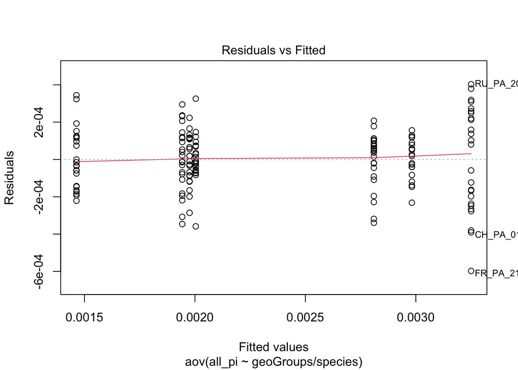

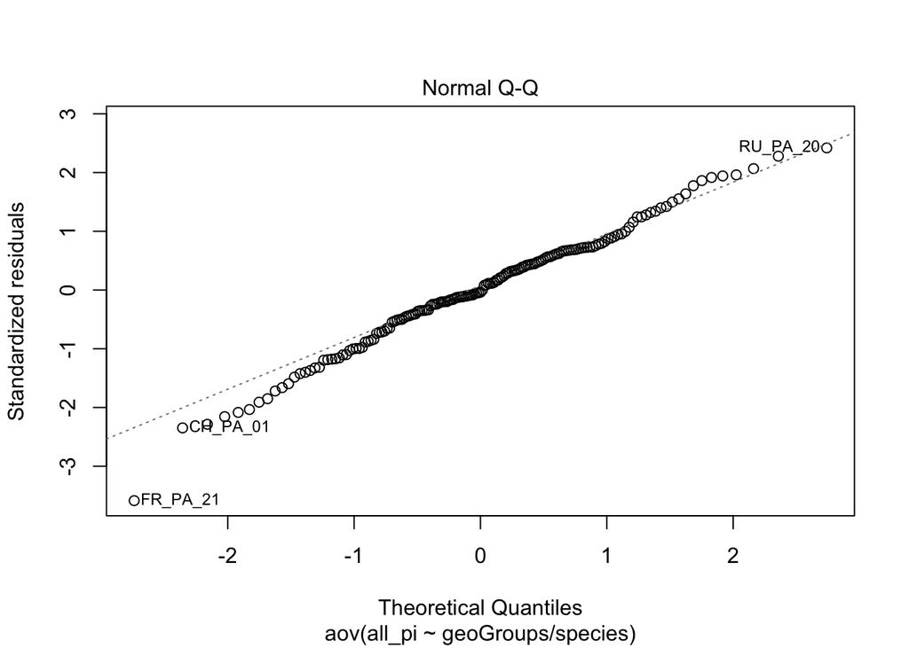

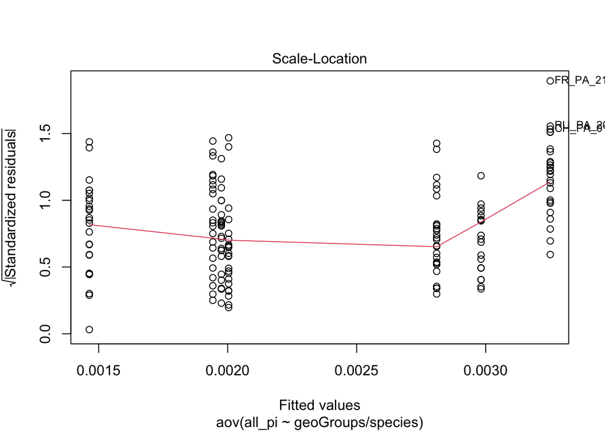

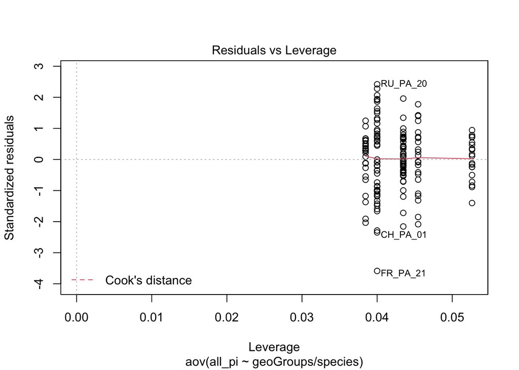

```r
plot(aov(all_pi ~ geoGroups/species, data = allDivGeo.rawStar.df))
```

```r
TukeyHSD(aov(all_pi ~ geoGroups/species, data = allDivGeo.rawStar.df))
```

```
##   Tukey multiple comparisons of means
##     95% family-wise confidence level
##
## Fit: aov(formula = all_pi ~ geoGroups/species, data = allDivGeo.rawStar.df)
##
## $geoGroups
##                          diff           lwr           upr p adj
## temperate-boreal -0.000161328 -0.0002143769 -0.0001082791     0
##
## $`geoGroups:species`
##                                    diff           lwr           upr     p adj
## temperate:BP-boreal:BP               NA            NA            NA        NA
## boreal:FS-boreal:BP                  NA            NA            NA        NA
## temperate:FS-boreal:BP     8.062579e-04  6.404330e-04  9.720827e-04 0.0000000
## boreal:PA-boreal:BP        1.246590e-03  1.079215e-03  1.413964e-03 0.0000000
## temperate:PA-boreal:BP               NA            NA            NA        NA
## boreal:PO-boreal:BP                  NA            NA            NA        NA
## temperate:PO-boreal:BP    -6.127591e-05 -2.340319e-04  1.114801e-04 0.9948954
## boreal:PP-boreal:BP                  NA            NA            NA        NA
## temperate:PP-boreal:BP    -5.400409e-04 -7.074152e-04 -3.726665e-04 0.0000000
## boreal:PS-boreal:BP       -2.815700e-05 -1.989827e-04  1.426687e-04 0.9999990
## temperate:PS-boreal:BP               NA            NA            NA        NA
## boreal:QP-boreal:BP                  NA            NA            NA        NA
## temperate:QP-boreal:BP     9.782914e-04  7.986998e-04  1.157883e-03 0.0000000
## boreal:FS-temperate:BP               NA            NA            NA        NA
## temperate:FS-temperate:BP            NA            NA            NA        NA
## boreal:PA-temperate:BP               NA            NA            NA        NA
## temperate:PA-temperate:BP            NA            NA            NA        NA
## boreal:PO-temperate:BP               NA            NA            NA        NA
## temperate:PO-temperate:BP            NA            NA            NA        NA
## boreal:PP-temperate:BP               NA            NA            NA        NA
## temperate:PP-temperate:BP            NA            NA            NA        NA
## boreal:PS-temperate:BP               NA            NA            NA        NA
## temperate:PS-temperate:BP            NA            NA            NA        NA
## boreal:QP-temperate:BP               NA            NA            NA        NA
## temperate:QP-temperate:BP            NA            NA            NA        NA
## temperate:FS-boreal:FS               NA            NA            NA        NA
## boreal:PA-boreal:FS                  NA            NA            NA        NA
## temperate:PA-boreal:FS               NA            NA            NA        NA
## boreal:PO-boreal:FS                  NA            NA            NA        NA
```

[output cut: 47 more lines]

```
## temperate:PP-boreal:PP               NA            NA            NA        NA
## boreal:PS-boreal:PP                  NA            NA            NA        NA
## temperate:PS-boreal:PP               NA            NA            NA        NA
## boreal:QP-boreal:PP                  NA            NA            NA        NA
## temperate:QP-boreal:PP               NA            NA            NA        NA
## boreal:PS-temperate:PP     5.118839e-04  3.445095e-04  6.792582e-04 0.0000000
## temperate:PS-temperate:PP            NA            NA            NA        NA
## boreal:QP-temperate:PP               NA            NA            NA        NA
## temperate:QP-temperate:PP  1.518332e-03  1.342020e-03  1.694644e-03 0.0000000
## temperate:PS-boreal:PS               NA            NA            NA        NA
## boreal:QP-boreal:PS                  NA            NA            NA        NA
## temperate:QP-boreal:PS     1.006448e-03  8.268568e-04  1.186040e-03 0.0000000
## boreal:QP-temperate:PS               NA            NA            NA        NA
## temperate:QP-temperate:PS            NA            NA            NA        NA
## temperate:QP-boreal:QP               NA            NA            NA        NA
```

```r
TukeyHSD(aov(all_pi ~ phyloGroups/species, data = allDivGeo.rawStar.df))
```

```
##   Tukey multiple comparisons of means
##     95% family-wise confidence level
##
## Fit: aov(formula = all_pi ~ phyloGroups/species, data = allDivGeo.rawStar.df)
##
## $phyloGroups
##                      diff           lwr           upr p adj
## gymno-angio -0.0001913712 -0.0002442664 -0.0001384759     0
##
## $`phyloGroups:species`
##                            diff           lwr           upr     p adj
## gymno:BP-angio:BP            NA            NA            NA        NA
## angio:FS-angio:BP  8.062579e-04  6.404330e-04  9.720827e-04 0.0000000
## gymno:FS-angio:BP            NA            NA            NA        NA
## angio:PA-angio:BP            NA            NA            NA        NA
## gymno:PA-angio:BP  1.246590e-03  1.079215e-03  1.413964e-03 0.0000000
## angio:PO-angio:BP -6.127591e-05 -2.340319e-04  1.114801e-04 0.9948954
## gymno:PO-angio:BP            NA            NA            NA        NA
## angio:PP-angio:BP            NA            NA            NA        NA
## gymno:PP-angio:BP -5.400409e-04 -7.074152e-04 -3.726665e-04 0.0000000
## angio:PS-angio:BP            NA            NA            NA        NA
## gymno:PS-angio:BP -2.815700e-05 -1.989827e-04  1.426687e-04 0.9999990
## angio:QP-angio:BP  9.782914e-04  7.986998e-04  1.157883e-03 0.0000000
## gymno:QP-angio:BP            NA            NA            NA        NA
## angio:FS-gymno:BP            NA            NA            NA        NA
## gymno:FS-gymno:BP            NA            NA            NA        NA
## angio:PA-gymno:BP            NA            NA            NA        NA
## gymno:PA-gymno:BP            NA            NA            NA        NA
## angio:PO-gymno:BP            NA            NA            NA        NA
## gymno:PO-gymno:BP            NA            NA            NA        NA
## angio:PP-gymno:BP            NA            NA            NA        NA
## gymno:PP-gymno:BP            NA            NA            NA        NA
## angio:PS-gymno:BP            NA            NA            NA        NA
## gymno:PS-gymno:BP            NA            NA            NA        NA
## angio:QP-gymno:BP            NA            NA            NA        NA
## gymno:QP-gymno:BP            NA            NA            NA        NA
## gymno:FS-angio:FS            NA            NA            NA        NA
## angio:PA-angio:FS            NA            NA            NA        NA
## gymno:PA-angio:FS  4.403319e-04  2.780647e-04  6.025990e-04 0.0000000
## angio:PO-angio:FS -8.675338e-04 -1.035346e-03 -6.997211e-04 0.0000000
```

[output cut: 47 more lines]

```
## gymno:PP-angio:PP            NA            NA            NA        NA
## angio:PS-angio:PP            NA            NA            NA        NA
## gymno:PS-angio:PP            NA            NA            NA        NA
## angio:QP-angio:PP            NA            NA            NA        NA
## gymno:QP-angio:PP            NA            NA            NA        NA
## angio:PS-gymno:PP            NA            NA            NA        NA
## gymno:PS-gymno:PP  5.118839e-04  3.445095e-04  6.792582e-04 0.0000000
## angio:QP-gymno:PP  1.518332e-03  1.342020e-03  1.694644e-03 0.0000000
## gymno:QP-gymno:PP            NA            NA            NA        NA
## gymno:PS-angio:PS            NA            NA            NA        NA
## angio:QP-angio:PS            NA            NA            NA        NA
## gymno:QP-angio:PS            NA            NA            NA        NA
## angio:QP-gymno:PS  1.006448e-03  8.268568e-04  1.186040e-03 0.0000000
## gymno:QP-gymno:PS            NA            NA            NA        NA
## gymno:QP-angio:QP            NA            NA            NA        NA
```

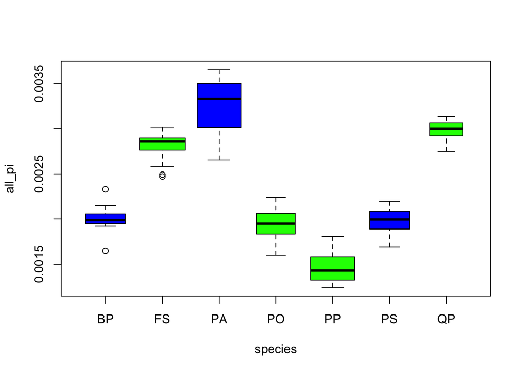

```r
proportion <- table(allDivGeo.rawStar.df$species) / nrow(allDivGeo.rawStar.df)
boxplot(allDivGeo.rawStar.df$all_pi ~ allDivGeo.rawStar.df$species, col = c("blue", "green", "blue", "green", "green", "blue","green"),
        width=proportion, ylab = "all_pi", xlab = "species")
```

```r
summary(glm(all_pi ~ latwgs84 * species, data = allDivGeo.rawStar.df))
```

```
##
## Call:
## glm(formula = all_pi ~ latwgs84 * species, data = allDivGeo.rawStar.df)
##
## Deviance Residuals:
##        Min          1Q      Median          3Q         Max
## -3.593e-04  -8.472e-05   1.045e-05   7.283e-05   3.496e-04
##
## Coefficients:
##                     Estimate Std. Error t value Pr(>|t|)
## (Intercept)        2.378e-03  9.527e-05  24.964  < 2e-16 ***
## latwgs84          -1.579e-06  2.042e-06  -0.773 0.440629
## species1          -6.394e-04  1.957e-04  -3.267 0.001349 **
## species2           1.147e-03  2.327e-04   4.930 2.17e-06 ***
## species3          -6.887e-04  1.863e-04  -3.696 0.000307 ***
## species4          -4.556e-05  2.981e-04  -0.153 0.878758
## species5          -6.333e-05  2.900e-04  -0.218 0.827427
## species6           4.914e-05  1.783e-04   0.276 0.783240
## latwgs84:species1  6.574e-06  3.791e-06   1.734 0.085004 .
## latwgs84:species2 -1.336e-05  4.855e-06  -2.751 0.006686 **
## latwgs84:species3  3.108e-05  3.626e-06   8.573 1.19e-14 ***
## latwgs84:species4 -7.015e-06  6.523e-06  -1.075 0.283898
## latwgs84:species5 -1.919e-05  6.964e-06  -2.756 0.006583 **
## latwgs84:species6 -7.082e-06  3.507e-06  -2.020 0.045222 *
## ---
## Signif. codes:  0 '***' 0.001 '**' 0.01 '*' 0.05 '.' 0.1 ' ' 1
##
## (Dispersion parameter for gaussian family taken to be 1.836527e-08)
##
##     Null deviance: 6.7130e-05  on 162  degrees of freedom
## Residual deviance: 2.7364e-06  on 149  degrees of freedom
## AIC: -2425.6
##
## Number of Fisher Scoring iterations: 2
```

```r
all_pi.glm <- glm(all_pi ~ latwgs84 * species, data = allDivGeo.rawStar.df)
# p <- ggplot(allDivGeo.rawStar.df, aes(x=latwgs84, y=pi_all, colour=species)) +
#   geom_point(size=3) +
#   #geom_line(aes(y=predict(pi_all.glm), group=Subject, size="Subjects")) +
#   geom_line(data=newdat, aes(y=predict(fm2, level=0, newdata=newdat), size="Population")) +
#   scale_size_manual(name="Predictions", values=c("Subjects"=0.5, "Population"=3)) +
#   theme_bw(base_size=22)
#defining generic function
divGLM <- function (x, y) #a function to collect all the lm on raw observations
  # x = numeric. Vector of dependent variable
  # y = array. Contains the explanatory variables
{
  tmp <- list()
  tmp[[1]] <- list(                                                                           # first element of the list is for LATITUDES
             glm(x ~ y$latwgs84 * y$species),
             lm(x[which(y$species == tail(levels(y$species),1))] ~                            # this returns the last species' lm,
                  latwgs84, data = subset(y, species == tail(levels(y$species),1))),          # independently of the general model above
             lm(x[which(y$geoGroups == "boreal")] ~
                  subset(y, geoGroups == "boreal")$latwgs84),
             lm(x[which(y$geoGroups == "temperate")] ~
                  subset(y, geoGroups == "temperate")$latwgs84),
             lm(x[which(y$phyloGroups == "gymno")] ~
                  subset(y, phyloGroups == "gymno")$latwgs84),
             lm(x[which(y$phyloGroups == "angio")] ~
                  subset(y, phyloGroups == "angio")$latwgs84))
 names(tmp[[1]]) <- c("Sp_glm", "lastSp_lm", "geo_glm", "lastGeoGroup_glm", "phylo_glm", "lastPhyloGroup_glm")
 tmp[[2]] <- list(                                                                           # second element of the list is for LONGITUDES
             glm(x ~ y$lonwgs84 * y$species),
             lm(x[which(y$species == tail(levels(y$species),1))] ~                           # this returns the last species' lm,
                  lonwgs84, data = subset(y, species == tail(levels(y$species),1))),         # independently of the general model above
             lm(x[which(y$geoGroups == "boreal")] ~
                  subset(y, geoGroups == "boreal")$lonwgs84),
             lm(x[which(y$geoGroups == "temperate")] ~
                  subset(y, geoGroups == "temperate")$lonwgs84),
             lm(x[which(y$phyloGroups == "gymno")] ~
                  subset(y, phyloGroups == "gymno")$lonwgs84),
             lm(x[which(y$phyloGroups == "angio")] ~
                  subset(y, phyloGroups == "angio")$lonwgs84))
 names(tmp[[2]]) <- c("Sp_glm", "lastSp_lm", "geo_glm", "lastGeoGroup_glm", "phylo_glm", "lastPhyloGroup_glm")
 names(tmp) <- c("lat", "lon")
 return(tmp)
}
GLMs_forPlotting <- apply(X = allDivGeo.rawStar.df[c(12,10,51)], MARGIN = 2, FUN = divGLM, y = allDivGeo.rawStar.df)
names(GLMs_forPlotting) <- names(allDivGeo.rawStar.df)[c(12,10,51)]
```

All the required coefficients have now been generated for plotting.

Notice that we will plot the raw values, not model residuals, along with the fitting straight lines corresponding to each species’ and each group’s models.

This way the fitting straight lines will correspond to each group’s scatter plot, but *the plot slopes do not correspond to a given group’s effect* - they are the sum of general slope and group slope. Same for intercepts.

## Plotting of raw dependencies of genDiv variables on Lat, Lon by species and species group

Approx line numbers for the start of chunks for each plot: * **Pi_all**: L 1213 + *Latitude*: L 1218 + *Longitude*: L 1366 * **Pi0/Pi4**: L 1496 + *Latitude*: L 1503 + *Longitude*: L 1640 * **sd_medianTheta**: L 1777 + *Latitude*: L 1783 + *Longitude*: L 1919

### Pi_all

```r
# reminder : 'pi_all' is second element of the GLMs_forPlotting list
#            'lat' is the first element of that element
pdf(file = "all_pi_latBYspecies.pdf")
plot(x = subset(allDivGeo.rawStar.df, species == "BP")$latwgs84,
     y = subset(allDivGeo.rawStar.df, species == "BP")$all_pi,
     xlim = c(min(allDivGeo.rawStar.df$latwgs84), max(allDivGeo.rawStar.df$latwgs84)),
     ylim = c(min(allDivGeo.rawStar.df$all_pi), max(allDivGeo.rawStar.df$all_pi)),
     col = "blue",
     xlab = "Latitude", ylab = "all_pi", main = "all_pi vs Lat")
# model for first species
curve((GLMs_forPlotting[[2]][[1]][[1]]$coefficients["y$latwgs84"]+
       GLMs_forPlotting[[2]][[1]][[1]]$coefficients["y$latwgs84:y$species1"])*x+
       GLMs_forPlotting[[2]][[1]][[1]]$coefficients["(Intercept)"]+
       GLMs_forPlotting[[2]][[1]][[1]]$coefficients["y$species1"],
      from = min(subset(allDivGeo.rawStar.df, species == "BP")$latwgs84),
      to = max(subset(allDivGeo.rawStar.df, species == "BP")$latwgs84),
      lty = "dashed", col = "blue", add = T)
# dots and modesl for all other species
points(x = subset(allDivGeo.rawStar.df, species == "FS")$latwgs84,
       y = subset(allDivGeo.rawStar.df, species == "FS")$all_pi,
       col = "green")
curve((GLMs_forPlotting[[2]][[1]][[1]]$coefficients["y$latwgs84"]+
       GLMs_forPlotting[[2]][[1]][[1]]$coefficients["y$latwgs84:y$species2"])*x+
       GLMs_forPlotting[[2]][[1]][[1]]$coefficients["(Intercept)"]+
       GLMs_forPlotting[[2]][[1]][[1]]$coefficients["y$species2"],
      from = min(subset(allDivGeo.rawStar.df, species == "FS")$latwgs84),
      to = max(subset(allDivGeo.rawStar.df, species == "FS")$latwgs84),
      lty = "dashed", col = "green", add = T)
points(x = subset(allDivGeo.rawStar.df, species == "PA")$latwgs84,
       y = subset(allDivGeo.rawStar.df, species == "PA")$all_pi,
       col = "darkgreen", pch = 0)
curve((GLMs_forPlotting[[2]][[1]][[1]]$coefficients["y$latwgs84"]+
       GLMs_forPlotting[[2]][[1]][[1]]$coefficients["y$latwgs84:y$species3"])*x+
       GLMs_forPlotting[[2]][[1]][[1]]$coefficients["(Intercept)"]+
       GLMs_forPlotting[[2]][[1]][[1]]$coefficients["y$species3"],
      from = min(subset(allDivGeo.rawStar.df, species == "PA")$latwgs84),
      to = max(subset(allDivGeo.rawStar.df, species == "PA")$latwgs84),
      lty = "dashed", col = "darkgreen", add = T)
points(x = subset(allDivGeo.rawStar.df, species == "PO")$latwgs84,
       y = subset(allDivGeo.rawStar.df, species == "PO")$all_pi,
       col = "orange", pch = 0)
curve((GLMs_forPlotting[[2]][[1]][[1]]$coefficients["y$latwgs84"]+
       GLMs_forPlotting[[2]][[1]][[1]]$coefficients["y$latwgs84:y$species4"])*x+
       GLMs_forPlotting[[2]][[1]][[1]]$coefficients["(Intercept)"]+
       GLMs_forPlotting[[2]][[1]][[1]]$coefficients["y$species4"],
      from = min(subset(allDivGeo.rawStar.df, species == "PO")$latwgs84),
      to = max(subset(allDivGeo.rawStar.df, species == "PO")$latwgs84),
      lty = "dashed", col = "orange", add = T)
points(x = subset(allDivGeo.rawStar.df, species == "PP")$latwgs84,
       y = subset(allDivGeo.rawStar.df, species == "PP")$all_pi,
       col = "purple", pch = 2)
curve((GLMs_forPlotting[[2]][[1]][[1]]$coefficients["y$latwgs84"]+
       GLMs_forPlotting[[2]][[1]][[1]]$coefficients["y$latwgs84:y$species5"])*x+
       GLMs_forPlotting[[2]][[1]][[1]]$coefficients["(Intercept)"]+
       GLMs_forPlotting[[2]][[1]][[1]]$coefficients["y$species5"],
      from = min(subset(allDivGeo.rawStar.df, species == "PP")$latwgs84),
      to = max(subset(allDivGeo.rawStar.df, species == "PP")$latwgs84),
      lty = "dashed", col = "purple", add = T)
points(x = subset(allDivGeo.rawStar.df, species == "PS")$latwgs84,
       y = subset(allDivGeo.rawStar.df, species == "PS")$all_pi,
       col = "red", pch = 2)
curve((GLMs_forPlotting[[2]][[1]][[1]]$coefficients["y$latwgs84"]+
       GLMs_forPlotting[[2]][[1]][[1]]$coefficients["y$latwgs84:y$species6"])*x+
       GLMs_forPlotting[[2]][[1]][[1]]$coefficients["(Intercept)"]+
       GLMs_forPlotting[[2]][[1]][[1]]$coefficients["y$species6"],
      from = min(subset(allDivGeo.rawStar.df, species == "PS")$latwgs84),
      to = max(subset(allDivGeo.rawStar.df, species == "PS")$latwgs84),
      lty = "dashed", col = "red", add = T)
points(x = subset(allDivGeo.rawStar.df, species == "QP")$latwgs84,
       y = subset(allDivGeo.rawStar.df, species == "QP")$all_pi,
       col = "brown", pch = 2)
curve((GLMs_forPlotting[[2]][[1]][[2]]$coefficients["latwgs84"])*x+
       GLMs_forPlotting[[2]][[1]][[2]]$coefficients["(Intercept)"],
      from = min(subset(allDivGeo.rawStar.df, species == "QP")$latwgs84),
      to = max(subset(allDivGeo.rawStar.df, species == "QP")$latwgs84),
      lty = "dashed", col = "brown", add = T)
## NOT USED
# overall mean
# curve((GLMs_forPlotting[[2]][[1]][[1]]$coefficients["y$latwgs84"])*x+
#        GLMs_forPlotting[[2]][[1]][[1]]$coefficients["(Intercept)"],
#       from = min(allDivGeo.rawStar.df$latwgs84),
#       to = max(allDivGeo.rawStar.df$latwgs84),
#       lwd = 2, col = "lightgrey", add = T)
text(labels = levels(allDivGeo.rawStar.df$species),
     x = c(65,61,65,35,33,65,60),
     y = c(0.0022,0.0027,0.0033,0.0021,0.00155,0.0017,0.0030),
     col = c("blue", "green", "darkgreen", "orange", "purple", "red", "brown"))
dev.off()
```

```r
# END OF PLOT for species
#
# phylo / geo group models
pdf(file = "all_pi_latBYgroup.pdf")
plot(x = subset(allDivGeo.rawStar.df, phyloGroups == "gymno" & geoGroups == "boreal")$latwgs84,
     y = subset(allDivGeo.rawStar.df,  phyloGroups == "gymno" & geoGroups == "boreal")$all_pi,
     xlim = c(min(allDivGeo.rawStar.df$latwgs84), max(allDivGeo.rawStar.df$latwgs84)),
     ylim = c(min(allDivGeo.rawStar.df$all_pi), max(allDivGeo.rawStar.df$all_pi)),
     pch = 24, bg = "slategrey",
     xlab = "Latitude", ylab = "all_pi", main = "all_pi vs Lat")
points(x = subset(allDivGeo.rawStar.df, phyloGroups == "gymno" & geoGroups == "temperate")$latwgs84,
     y = subset(allDivGeo.rawStar.df,  phyloGroups == "gymno" & geoGroups == "temperate")$all_pi,
     pch = 24, bg = "white")
points(x = subset(allDivGeo.rawStar.df, phyloGroups == "angio" & geoGroups == "boreal")$latwgs84,
     y = subset(allDivGeo.rawStar.df,  phyloGroups == "angio" & geoGroups == "boreal")$all_pi,
     pch = 21, bg = "slategrey")
points(x = subset(allDivGeo.rawStar.df, phyloGroups == "angio" & geoGroups == "temperate")$latwgs84,
     y = subset(allDivGeo.rawStar.df,  phyloGroups == "angio" & geoGroups == "temperate")$all_pi,
     pch = 21, bg = "white")
#
curve((GLMs_forPlotting[[2]][[1]][[5]]$coefficients[2])*x+
       GLMs_forPlotting[[2]][[1]][[5]]$coefficients["(Intercept)"],
      from = min(subset(allDivGeo.rawStar.df, phyloGroups == "gymno")$latwgs84),
      to = max(subset(allDivGeo.rawStar.df, phyloGroups == "gymno")$latwgs84),
      col = "black", lty = "dotted", lwd = 2, add = T)
curve((GLMs_forPlotting[[2]][[1]][[6]]$coefficients[2])*x+
       GLMs_forPlotting[[2]][[1]][[6]]$coefficients["(Intercept)"],
      from = min(subset(allDivGeo.rawStar.df, phyloGroups == "angio")$latwgs84),
      to = max(subset(allDivGeo.rawStar.df, phyloGroups == "angio")$latwgs84),
      col = "black", lty = "dashed", add = T)
curve((GLMs_forPlotting[[2]][[1]][[3]]$coefficients[2])*x+
       GLMs_forPlotting[[2]][[1]][[3]]$coefficients["(Intercept)"],
      from = min(subset(allDivGeo.rawStar.df, geoGroups == "boreal")$latwgs84),
      to = max(subset(allDivGeo.rawStar.df, geoGroups == "boreal")$latwgs84),
      col = "black", add = T)
curve((GLMs_forPlotting[[2]][[1]][[4]]$coefficients[2])*x+
       GLMs_forPlotting[[2]][[1]][[4]]$coefficients["(Intercept)"],
      from = min(subset(allDivGeo.rawStar.df, geoGroups == "temperate")$latwgs84),
      to = max(subset(allDivGeo.rawStar.df, geoGroups == "temperate")$latwgs84),
      col = "gray", lwd = 2, add = T)
text(labels = c(levels(allDivGeo.rawStar.df$phyloGroups)[2:1],levels(allDivGeo.rawStar.df$geoGroups)),
     x = c(65,35,65,35),
     y = c(0.0031,0.0026,0.00265,0.0019))
dev.off()
```

```r
# reminder : 'pi_all' is second element of the GLMs_forPlotting list
#            'lon' is the second element of that element
pdf(file = "all_pi_lonBYspecies.pdf")
plot(x = subset(allDivGeo.rawStar.df, species == "BP")$lonwgs84,
     y = subset(allDivGeo.rawStar.df, species == "BP")$all_pi,
     xlim = c(min(allDivGeo.rawStar.df$lonwgs84), max(allDivGeo.rawStar.df$lonwgs84)),
     ylim = c(min(allDivGeo.rawStar.df$all_pi), max(allDivGeo.rawStar.df$all_pi)),
     col = "blue",
     xlab = "longitude", ylab = "all_pi", main = "all_pi vs lon")
# model for first species
curve((GLMs_forPlotting[[2]][[2]][[1]]$coefficients["y$lonwgs84"]+
       GLMs_forPlotting[[2]][[2]][[1]]$coefficients["y$lonwgs84:y$species1"])*x+
       GLMs_forPlotting[[2]][[2]][[1]]$coefficients["(Intercept)"]+
       GLMs_forPlotting[[2]][[2]][[1]]$coefficients["y$species1"],
      from = min(subset(allDivGeo.rawStar.df, species == "BP")$lonwgs84),
      to = max(subset(allDivGeo.rawStar.df, species == "BP")$lonwgs84),
      lty = "dashed", col = "blue", add = T)
# dots and modesl for all other species
points(x = subset(allDivGeo.rawStar.df, species == "FS")$lonwgs84,
       y = subset(allDivGeo.rawStar.df, species == "FS")$all_pi,
       col = "green")
curve((GLMs_forPlotting[[2]][[2]][[1]]$coefficients["y$lonwgs84"]+
       GLMs_forPlotting[[2]][[2]][[1]]$coefficients["y$lonwgs84:y$species2"])*x+
       GLMs_forPlotting[[2]][[2]][[1]]$coefficients["(Intercept)"]+
       GLMs_forPlotting[[2]][[2]][[1]]$coefficients["y$species2"],
      from = min(subset(allDivGeo.rawStar.df, species == "FS")$lonwgs84),
      to = max(subset(allDivGeo.rawStar.df, species == "FS")$lonwgs84),
      lty = "dashed", col = "green", add = T)
points(x = subset(allDivGeo.rawStar.df, species == "PA")$lonwgs84,
       y = subset(allDivGeo.rawStar.df, species == "PA")$all_pi,
       col = "darkgreen", pch = 0)
curve((GLMs_forPlotting[[2]][[2]][[1]]$coefficients["y$lonwgs84"]+
       GLMs_forPlotting[[2]][[2]][[1]]$coefficients["y$lonwgs84:y$species3"])*x+
       GLMs_forPlotting[[2]][[2]][[1]]$coefficients["(Intercept)"]+
       GLMs_forPlotting[[2]][[2]][[1]]$coefficients["y$species3"],
      from = min(subset(allDivGeo.rawStar.df, species == "PA")$lonwgs84),
      to = max(subset(allDivGeo.rawStar.df, species == "PA")$lonwgs84),
      lty = "dashed", col = "darkgreen", add = T)
points(x = subset(allDivGeo.rawStar.df, species == "PO")$lonwgs84,
       y = subset(allDivGeo.rawStar.df, species == "PO")$all_pi,
       col = "orange", pch = 0)
curve((GLMs_forPlotting[[2]][[2]][[1]]$coefficients["y$lonwgs84"]+
       GLMs_forPlotting[[2]][[2]][[1]]$coefficients["y$lonwgs84:y$species4"])*x+
       GLMs_forPlotting[[2]][[2]][[1]]$coefficients["(Intercept)"]+
       GLMs_forPlotting[[2]][[2]][[1]]$coefficients["y$species4"],
      from = min(subset(allDivGeo.rawStar.df, species == "PO")$lonwgs84),
      to = max(subset(allDivGeo.rawStar.df, species == "PO")$lonwgs84),
      lty = "dashed", col = "orange", add = T)
points(x = subset(allDivGeo.rawStar.df, species == "PP")$lonwgs84,
       y = subset(allDivGeo.rawStar.df, species == "PP")$all_pi,
       col = "purple", pch = 2)
curve((GLMs_forPlotting[[2]][[2]][[1]]$coefficients["y$lonwgs84"]+
       GLMs_forPlotting[[2]][[2]][[1]]$coefficients["y$lonwgs84:y$species5"])*x+
       GLMs_forPlotting[[2]][[2]][[1]]$coefficients["(Intercept)"]+
       GLMs_forPlotting[[2]][[2]][[1]]$coefficients["y$species5"],
      from = min(subset(allDivGeo.rawStar.df, species == "PP")$lonwgs84),
      to = max(subset(allDivGeo.rawStar.df, species == "PP")$lonwgs84),
      lty = "dashed", col = "purple", add = T)
points(x = subset(allDivGeo.rawStar.df, species == "PS")$lonwgs84,
       y = subset(allDivGeo.rawStar.df, species == "PS")$all_pi,
       col = "red", pch = 2)
curve((GLMs_forPlotting[[2]][[2]][[1]]$coefficients["y$lonwgs84"]+
       GLMs_forPlotting[[2]][[2]][[1]]$coefficients["y$lonwgs84:y$species6"])*x+
       GLMs_forPlotting[[2]][[2]][[1]]$coefficients["(Intercept)"]+
       GLMs_forPlotting[[2]][[2]][[1]]$coefficients["y$species6"],
      from = min(subset(allDivGeo.rawStar.df, species == "PS")$lonwgs84),
      to = max(subset(allDivGeo.rawStar.df, species == "PS")$lonwgs84),
      lty = "dashed", col = "red", add = T)
points(x = subset(allDivGeo.rawStar.df, species == "QP")$lonwgs84,
       y = subset(allDivGeo.rawStar.df, species == "QP")$all_pi,
       col = "brown", pch = 2)
curve((GLMs_forPlotting[[2]][[2]][[2]]$coefficients["lonwgs84"])*x+
       GLMs_forPlotting[[2]][[2]][[2]]$coefficients["(Intercept)"],
      from = min(subset(allDivGeo.rawStar.df, species == "QP")$lonwgs84),
      to = max(subset(allDivGeo.rawStar.df, species == "QP")$lonwgs84),
      lty = "dashed", col = "brown", add = T)
## NOT USED
# overall mean
# curve((GLMs_forPlotting[[2]][[1]][[1]]$coefficients["y$lonwgs84"])*x+
#        GLMs_forPlotting[[2]][[2]][[1]]$coefficients["(Intercept)"],
#       from = min(allDivGeo.rawStar.df$lonwgs84),
#       to = max(allDivGeo.rawStar.df$lonwgs84),
#       lwd = 2, col = "lightgrey", add = T)
text(labels = levels(allDivGeo.rawStar.df$species),
     x = c(82,-5,65,19,18,65,30),
     y = c(0.0021,0.0027,0.0035,0.0017,0.0013,0.0017,0.0029),
     col = c("blue", "green", "darkgreen", "orange", "purple", "red", "brown"))
dev.off()
```

```r
# END OF PLOT for species
#
# phylo / geo group models
pdf(file = "all_pi_lonBYgroup.pdf")
plot(x = subset(allDivGeo.rawStar.df, phyloGroups == "gymno" & geoGroups == "boreal")$lonwgs84,
     y = subset(allDivGeo.rawStar.df,  phyloGroups == "gymno" & geoGroups == "boreal")$all_pi,
     xlim = c(min(allDivGeo.rawStar.df$lonwgs84), max(allDivGeo.rawStar.df$lonwgs84)),
     ylim = c(min(allDivGeo.rawStar.df$all_pi), max(allDivGeo.rawStar.df$all_pi)),
     pch = 24, bg = "slategrey",
     xlab = "Longitude", ylab = "all_pi", main = "all_pi vs lon")
points(x = subset(allDivGeo.rawStar.df, phyloGroups == "gymno" & geoGroups == "temperate")$lonwgs84,
     y = subset(allDivGeo.rawStar.df,  phyloGroups == "gymno" & geoGroups == "temperate")$all_pi,
     pch = 24, bg = "white")
points(x = subset(allDivGeo.rawStar.df, phyloGroups == "angio" & geoGroups == "boreal")$lonwgs84,
     y = subset(allDivGeo.rawStar.df,  phyloGroups == "angio" & geoGroups == "boreal")$all_pi,
     pch = 21, bg = "slategrey")
points(x = subset(allDivGeo.rawStar.df, phyloGroups == "angio" & geoGroups == "temperate")$lonwgs84,
     y = subset(allDivGeo.rawStar.df,  phyloGroups == "angio" & geoGroups == "temperate")$all_pi,
     pch = 21, bg = "white")
#
curve((GLMs_forPlotting[[2]][[2]][[5]]$coefficients[2])*x+
       GLMs_forPlotting[[2]][[2]][[5]]$coefficients["(Intercept)"],
      from = min(subset(allDivGeo.rawStar.df, phyloGroups == "gymno")$lonwgs84),
      to = max(subset(allDivGeo.rawStar.df, phyloGroups == "gymno")$lonwgs84),
      col = "black", lty = "dotted", lwd = 2, add = T)
curve((GLMs_forPlotting[[2]][[2]][[6]]$coefficients[2])*x+
       GLMs_forPlotting[[2]][[2]][[6]]$coefficients["(Intercept)"],
      from = min(subset(allDivGeo.rawStar.df, phyloGroups == "angio")$lonwgs84),
      to = max(subset(allDivGeo.rawStar.df, phyloGroups == "angio")$lonwgs84),
      col = "black", lty = "dashed", add = T)
curve((GLMs_forPlotting[[2]][[2]][[3]]$coefficients[2])*x+
       GLMs_forPlotting[[2]][[2]][[3]]$coefficients["(Intercept)"],
      from = min(subset(allDivGeo.rawStar.df, geoGroups == "boreal")$lonwgs84),
      to = max(subset(allDivGeo.rawStar.df, geoGroups == "boreal")$lonwgs84),
      col = "black", add = T)
curve((GLMs_forPlotting[[2]][[2]][[4]]$coefficients[2])*x+
       GLMs_forPlotting[[2]][[2]][[4]]$coefficients["(Intercept)"],
      from = min(subset(allDivGeo.rawStar.df, geoGroups == "temperate")$lonwgs84),
      to = max(subset(allDivGeo.rawStar.df, geoGroups == "temperate")$lonwgs84),
      col = "gray", lwd = 2, add = T)
text(labels = c(levels(allDivGeo.rawStar.df$phyloGroups)[2:1],levels(allDivGeo.rawStar.df$geoGroups)),
     x = c(60,70,80,20),
     y = c(0.0031,0.0022,0.0031,0.0027))
dev.off()
```

### Pi0/Pi4

Latitude:

```r
# reminder : 'pi0div4' is first element of the 'GLMs_forPlotting' list
#            'lat' is the first element of that element
pdf(file = "pi0div4_latBYspecies.pdf")
plot(x = subset(allDivGeo.rawStar.df, species == "BP")$latwgs84,
     y = subset(allDivGeo.rawStar.df, species == "BP")$pi0div4,
     xlim = c(min(allDivGeo.rawStar.df$latwgs84), max(allDivGeo.rawStar.df$latwgs84)),
     ylim = c(min(allDivGeo.rawStar.df$pi0div4), max(allDivGeo.rawStar.df$pi0div4)),
     col = "blue",
     xlab = "Latitude", ylab = "pi0div4", main = "pi0div4 vs Lat")
# model for first species
curve((GLMs_forPlotting[[1]][[1]][[1]]$coefficients["y$latwgs84"]+
       GLMs_forPlotting[[1]][[1]][[1]]$coefficients["y$latwgs84:y$species1"])*x+
       GLMs_forPlotting[[1]][[1]][[1]]$coefficients["(Intercept)"]+
       GLMs_forPlotting[[1]][[1]][[1]]$coefficients["y$species1"],
      from = min(subset(allDivGeo.rawStar.df, species == "BP")$latwgs84),
      to = max(subset(allDivGeo.rawStar.df, species == "BP")$latwgs84),
      lty = "dashed", col = "blue", add = T)
# dots and modesl for all other species
points(x = subset(allDivGeo.rawStar.df, species == "FS")$latwgs84,
       y = subset(allDivGeo.rawStar.df, species == "FS")$pi0div4,
       col = "green")
curve((GLMs_forPlotting[[1]][[1]][[1]]$coefficients["y$latwgs84"]+
       GLMs_forPlotting[[1]][[1]][[1]]$coefficients["y$latwgs84:y$species2"])*x+
       GLMs_forPlotting[[1]][[1]][[1]]$coefficients["(Intercept)"]+
       GLMs_forPlotting[[1]][[1]][[1]]$coefficients["y$species2"],
      from = min(subset(allDivGeo.rawStar.df, species == "FS")$latwgs84),
      to = max(subset(allDivGeo.rawStar.df, species == "FS")$latwgs84),
      lty = "dashed", col = "green", add = T)
points(x = subset(allDivGeo.rawStar.df, species == "PA")$latwgs84,
       y = subset(allDivGeo.rawStar.df, species == "PA")$pi0div4,
       col = "darkgreen", pch = 0)
curve((GLMs_forPlotting[[1]][[1]][[1]]$coefficients["y$latwgs84"]+
       GLMs_forPlotting[[1]][[1]][[1]]$coefficients["y$latwgs84:y$species3"])*x+
       GLMs_forPlotting[[1]][[1]][[1]]$coefficients["(Intercept)"]+
       GLMs_forPlotting[[1]][[1]][[1]]$coefficients["y$species3"],
      from = min(subset(allDivGeo.rawStar.df, species == "PA")$latwgs84),
      to = max(subset(allDivGeo.rawStar.df, species == "PA")$latwgs84),
      lty = "dashed", col = "darkgreen", add = T)
points(x = subset(allDivGeo.rawStar.df, species == "PO")$latwgs84,
       y = subset(allDivGeo.rawStar.df, species == "PO")$pi0div4,
       col = "orange", pch = 0)
curve((GLMs_forPlotting[[1]][[1]][[1]]$coefficients["y$latwgs84"]+
       GLMs_forPlotting[[1]][[1]][[1]]$coefficients["y$latwgs84:y$species4"])*x+
       GLMs_forPlotting[[1]][[1]][[1]]$coefficients["(Intercept)"]+
       GLMs_forPlotting[[1]][[1]][[1]]$coefficients["y$species4"],
      from = min(subset(allDivGeo.rawStar.df, species == "PO")$latwgs84),
      to = max(subset(allDivGeo.rawStar.df, species == "PO")$latwgs84),
      lty = "dashed", col = "orange", add = T)
points(x = subset(allDivGeo.rawStar.df, species == "PP")$latwgs84,
       y = subset(allDivGeo.rawStar.df, species == "PP")$pi0div4,
       col = "purple", pch = 2)
curve((GLMs_forPlotting[[1]][[1]][[1]]$coefficients["y$latwgs84"]+
       GLMs_forPlotting[[1]][[1]][[1]]$coefficients["y$latwgs84:y$species5"])*x+
       GLMs_forPlotting[[1]][[1]][[1]]$coefficients["(Intercept)"]+
       GLMs_forPlotting[[1]][[1]][[1]]$coefficients["y$species5"],
      from = min(subset(allDivGeo.rawStar.df, species == "PP")$latwgs84),
      to = max(subset(allDivGeo.rawStar.df, species == "PP")$latwgs84),
      lty = "dashed", col = "purple", add = T)
points(x = subset(allDivGeo.rawStar.df, species == "PS")$latwgs84,
       y = subset(allDivGeo.rawStar.df, species == "PS")$pi0div4,
       col = "red", pch = 2)
curve((GLMs_forPlotting[[1]][[1]][[1]]$coefficients["y$latwgs84"]+
       GLMs_forPlotting[[1]][[1]][[1]]$coefficients["y$latwgs84:y$species6"])*x+
       GLMs_forPlotting[[1]][[1]][[1]]$coefficients["(Intercept)"]+
       GLMs_forPlotting[[1]][[1]][[1]]$coefficients["y$species6"],
      from = min(subset(allDivGeo.rawStar.df, species == "PS")$latwgs84),
      to = max(subset(allDivGeo.rawStar.df, species == "PS")$latwgs84),
      lty = "dashed", col = "red", add = T)
points(x = subset(allDivGeo.rawStar.df, species == "QP")$latwgs84,
       y = subset(allDivGeo.rawStar.df, species == "QP")$pi0div4,
       col = "brown", pch = 2)
curve((GLMs_forPlotting[[1]][[1]][[2]]$coefficients["latwgs84"])*x+
       GLMs_forPlotting[[1]][[1]][[2]]$coefficients["(Intercept)"],
      from = min(subset(allDivGeo.rawStar.df, species == "QP")$latwgs84),
      to = max(subset(allDivGeo.rawStar.df, species == "QP")$latwgs84),
      lty = "dashed", col = "brown", add = T)
## NOT USED
# overall mean
# curve((GLMs_forPlotting[[1]][[1]][[1]]$coefficients["y$latwgs84"])*x+
#        GLMs_forPlotting[[1]][[1]][[1]]$coefficients["(Intercept)"],
#       from = min(allDivGeo.rawStar.df$latwgs84),
#       to = max(allDivGeo.rawStar.df$latwgs84),
#       lwd = 2, col = "lightgrey", add = T)
text(labels = levels(allDivGeo.rawStar.df$species),
     x = c(65,61,39,35,35,38,61),
     y = c(0.22,0.24,0.37,0.27,0.31,0.47,0.26),
     col = c("blue", "green", "darkgreen", "orange", "purple", "red", "brown"))
dev.off()
```

```r
# END OF PLOT for species
#
# phylo / geo group models
pdf(file = "pi0div4_latBYgroup.pdf")
plot(x = subset(allDivGeo.rawStar.df, phyloGroups == "gymno" & geoGroups == "boreal")$latwgs84,
     y = subset(allDivGeo.rawStar.df,  phyloGroups == "gymno" & geoGroups == "boreal")$pi0div4,
     xlim = c(min(allDivGeo.rawStar.df$latwgs84), max(allDivGeo.rawStar.df$latwgs84)),
     ylim = c(min(allDivGeo.rawStar.df$pi0div4), max(allDivGeo.rawStar.df$pi0div4)),
     pch = 24, bg = "slategrey",
     xlab = "Latitude", ylab = "pi0div4", main = "pi0div4 vs Lat")
points(x = subset(allDivGeo.rawStar.df, phyloGroups == "gymno" & geoGroups == "temperate")$latwgs84,
     y = subset(allDivGeo.rawStar.df,  phyloGroups == "gymno" & geoGroups == "temperate")$pi0div4,
     pch = 24, bg = "white")
points(x = subset(allDivGeo.rawStar.df, phyloGroups == "angio" & geoGroups == "boreal")$latwgs84,
     y = subset(allDivGeo.rawStar.df,  phyloGroups == "angio" & geoGroups == "boreal")$pi0div4,
     pch = 21, bg = "slategrey")
points(x = subset(allDivGeo.rawStar.df, phyloGroups == "angio" & geoGroups == "temperate")$latwgs84,
     y = subset(allDivGeo.rawStar.df,  phyloGroups == "angio" & geoGroups == "temperate")$pi0div4,
     pch = 21, bg = "white")
#
curve((GLMs_forPlotting[[1]][[1]][[5]]$coefficients[2])*x+
       GLMs_forPlotting[[1]][[1]][[5]]$coefficients["(Intercept)"],
      from = min(subset(allDivGeo.rawStar.df, phyloGroups == "gymno")$latwgs84),
      to = max(subset(allDivGeo.rawStar.df, phyloGroups == "gymno")$latwgs84),
      col = "black", lty = "dotted", lwd = 2, add = T)
curve((GLMs_forPlotting[[1]][[1]][[6]]$coefficients[2])*x+
       GLMs_forPlotting[[1]][[1]][[6]]$coefficients["(Intercept)"],
      from = min(subset(allDivGeo.rawStar.df, phyloGroups == "angio")$latwgs84),
      to = max(subset(allDivGeo.rawStar.df, phyloGroups == "angio")$latwgs84),
      col = "black", lty = "dashed", add = T)
curve((GLMs_forPlotting[[1]][[1]][[3]]$coefficients[2])*x+
       GLMs_forPlotting[[1]][[1]][[3]]$coefficients["(Intercept)"],
      from = min(subset(allDivGeo.rawStar.df, geoGroups == "boreal")$latwgs84),
      to = max(subset(allDivGeo.rawStar.df, geoGroups == "boreal")$latwgs84),
      col = "black", add = T)
curve((GLMs_forPlotting[[1]][[1]][[4]]$coefficients[2])*x+
       GLMs_forPlotting[[1]][[1]][[4]]$coefficients["(Intercept)"],
      from = min(subset(allDivGeo.rawStar.df, geoGroups == "temperate")$latwgs84),
      to = max(subset(allDivGeo.rawStar.df, geoGroups == "temperate")$latwgs84),
      col = "gray", lwd = 2, add = T)
text(labels = c(levels(allDivGeo.rawStar.df$phyloGroups)[2:1],levels(allDivGeo.rawStar.df$geoGroups)),
     x = c(62,65,65,62),
     y = c(0.40,0.23,0.32,0.27))
dev.off()
```

Longitude:

```r
# reminder : 'pi0div4' is the first element of the GLMs_forPlotting list
#            'lon' is the second element of that element
pdf(file = "pi0div4_lonBYspecies.pdf")
plot(x = subset(allDivGeo.rawStar.df, species == "BP")$lonwgs84,
     y = subset(allDivGeo.rawStar.df, species == "BP")$pi0div4,
     xlim = c(min(allDivGeo.rawStar.df$lonwgs84), max(allDivGeo.rawStar.df$lonwgs84)),
     ylim = c(min(allDivGeo.rawStar.df$pi0div4), max(allDivGeo.rawStar.df$pi0div4)),
     col = "blue",
     xlab = "longitude", ylab = "pi0div4", main = "pi0div4 vs lon")
# model for first species
curve((GLMs_forPlotting[[1]][[2]][[1]]$coefficients["y$lonwgs84"]+
       GLMs_forPlotting[[1]][[2]][[1]]$coefficients["y$lonwgs84:y$species1"])*x+
       GLMs_forPlotting[[1]][[2]][[1]]$coefficients["(Intercept)"]+
       GLMs_forPlotting[[1]][[2]][[1]]$coefficients["y$species1"],
      from = min(subset(allDivGeo.rawStar.df, species == "BP")$lonwgs84),
      to = max(subset(allDivGeo.rawStar.df, species == "BP")$lonwgs84),
      lty = "dashed", col = "blue", add = T)
# dots and modesl for all other species
points(x = subset(allDivGeo.rawStar.df, species == "FS")$lonwgs84,
       y = subset(allDivGeo.rawStar.df, species == "FS")$pi0div4,
       col = "green")
curve((GLMs_forPlotting[[1]][[2]][[1]]$coefficients["y$lonwgs84"]+
       GLMs_forPlotting[[1]][[2]][[1]]$coefficients["y$lonwgs84:y$species2"])*x+
       GLMs_forPlotting[[1]][[2]][[1]]$coefficients["(Intercept)"]+
       GLMs_forPlotting[[1]][[2]][[1]]$coefficients["y$species2"],
      from = min(subset(allDivGeo.rawStar.df, species == "FS")$lonwgs84),
      to = max(subset(allDivGeo.rawStar.df, species == "FS")$lonwgs84),
      lty = "dashed", col = "green", add = T)
points(x = subset(allDivGeo.rawStar.df, species == "PA")$lonwgs84,
       y = subset(allDivGeo.rawStar.df, species == "PA")$pi0div4,
       col = "darkgreen", pch = 0)
curve((GLMs_forPlotting[[1]][[2]][[1]]$coefficients["y$lonwgs84"]+
       GLMs_forPlotting[[1]][[2]][[1]]$coefficients["y$lonwgs84:y$species3"])*x+
       GLMs_forPlotting[[1]][[2]][[1]]$coefficients["(Intercept)"]+
       GLMs_forPlotting[[1]][[2]][[1]]$coefficients["y$species3"],
      from = min(subset(allDivGeo.rawStar.df, species == "PA")$lonwgs84),
      to = max(subset(allDivGeo.rawStar.df, species == "PA")$lonwgs84),
      lty = "dashed", col = "darkgreen", add = T)
points(x = subset(allDivGeo.rawStar.df, species == "PO")$lonwgs84,
       y = subset(allDivGeo.rawStar.df, species == "PO")$pi0div4,
       col = "orange", pch = 0)
curve((GLMs_forPlotting[[1]][[2]][[1]]$coefficients["y$lonwgs84"]+
       GLMs_forPlotting[[1]][[2]][[1]]$coefficients["y$lonwgs84:y$species4"])*x+
       GLMs_forPlotting[[1]][[2]][[1]]$coefficients["(Intercept)"]+
       GLMs_forPlotting[[1]][[2]][[1]]$coefficients["y$species4"],
      from = min(subset(allDivGeo.rawStar.df, species == "PO")$lonwgs84),
      to = max(subset(allDivGeo.rawStar.df, species == "PO")$lonwgs84),
      lty = "dashed", col = "orange", add = T)
points(x = subset(allDivGeo.rawStar.df, species == "PP")$lonwgs84,
       y = subset(allDivGeo.rawStar.df, species == "PP")$pi0div4,
       col = "purple", pch = 2)
curve((GLMs_forPlotting[[1]][[2]][[1]]$coefficients["y$lonwgs84"]+
       GLMs_forPlotting[[1]][[2]][[1]]$coefficients["y$lonwgs84:y$species5"])*x+
       GLMs_forPlotting[[1]][[2]][[1]]$coefficients["(Intercept)"]+
       GLMs_forPlotting[[1]][[2]][[1]]$coefficients["y$species5"],
      from = min(subset(allDivGeo.rawStar.df, species == "PP")$lonwgs84),
      to = max(subset(allDivGeo.rawStar.df, species == "PP")$lonwgs84),
      lty = "dashed", col = "purple", add = T)
points(x = subset(allDivGeo.rawStar.df, species == "PS")$lonwgs84,
       y = subset(allDivGeo.rawStar.df, species == "PS")$pi0div4,
       col = "red", pch = 2)
curve((GLMs_forPlotting[[1]][[2]][[1]]$coefficients["y$lonwgs84"]+
       GLMs_forPlotting[[1]][[2]][[1]]$coefficients["y$lonwgs84:y$species6"])*x+
       GLMs_forPlotting[[1]][[2]][[1]]$coefficients["(Intercept)"]+
       GLMs_forPlotting[[1]][[2]][[1]]$coefficients["y$species6"],
      from = min(subset(allDivGeo.rawStar.df, species == "PS")$lonwgs84),
      to = max(subset(allDivGeo.rawStar.df, species == "PS")$lonwgs84),
      lty = "dashed", col = "red", add = T)
points(x = subset(allDivGeo.rawStar.df, species == "QP")$lonwgs84,
       y = subset(allDivGeo.rawStar.df, species == "QP")$pi0div4,
       col = "brown", pch = 2)
curve((GLMs_forPlotting[[1]][[2]][[2]]$coefficients["lonwgs84"])*x+
       GLMs_forPlotting[[1]][[2]][[2]]$coefficients["(Intercept)"],
      from = min(subset(allDivGeo.rawStar.df, species == "QP")$lonwgs84),
      to = max(subset(allDivGeo.rawStar.df, species == "QP")$lonwgs84),
      lty = "dashed", col = "brown", add = T)
## NOT USED
# overall mean
# curve((GLMs_forPlotting[[1]][[1]][[1]]$coefficients["y$lonwgs84"])*x+
#        GLMs_forPlotting[[1]][[2]][[1]]$coefficients["(Intercept)"],
#       from = min(allDivGeo.rawStar.df$lonwgs84),
#       to = max(allDivGeo.rawStar.df$lonwgs84),
#       lwd = 2, col = "lightgrey", add = T)
text(labels = levels(allDivGeo.rawStar.df$species),
     x = c(80,-5,65,-10,0,65,30),
     y = c(0.23,0.24,0.37,0.27,0.32,0.45,0.26),
     col = c("blue", "green", "darkgreen", "orange", "purple", "red", "brown"))
dev.off()
```

```r
# END OF PLOT for species
#
# phylo / geo group models
pdf(file = "pi0div4_lonBYgroup.pdf")
plot(x = subset(allDivGeo.rawStar.df, phyloGroups == "gymno" & geoGroups == "boreal")$lonwgs84,
     y = subset(allDivGeo.rawStar.df,  phyloGroups == "gymno" & geoGroups == "boreal")$pi0div4,
     xlim = c(min(allDivGeo.rawStar.df$lonwgs84), max(allDivGeo.rawStar.df$lonwgs84)),
     ylim = c(min(allDivGeo.rawStar.df$pi0div4), max(allDivGeo.rawStar.df$pi0div4)),
     pch = 24, bg = "slategrey",
     xlab = "Longitude", ylab = "pi0div4", main = "pi0div4 vs lon")
points(x = subset(allDivGeo.rawStar.df, phyloGroups == "gymno" & geoGroups == "temperate")$lonwgs84,
     y = subset(allDivGeo.rawStar.df,  phyloGroups == "gymno" & geoGroups == "temperate")$pi0div4,
     pch = 24, bg = "white")
points(x = subset(allDivGeo.rawStar.df, phyloGroups == "angio" & geoGroups == "boreal")$lonwgs84,
     y = subset(allDivGeo.rawStar.df,  phyloGroups == "angio" & geoGroups == "boreal")$pi0div4,
     pch = 21, bg = "slategrey")
points(x = subset(allDivGeo.rawStar.df, phyloGroups == "angio" & geoGroups == "temperate")$lonwgs84,
     y = subset(allDivGeo.rawStar.df,  phyloGroups == "angio" & geoGroups == "temperate")$pi0div4,
     pch = 21, bg = "white")
#
curve((GLMs_forPlotting[[1]][[2]][[5]]$coefficients[2])*x+
       GLMs_forPlotting[[1]][[2]][[5]]$coefficients["(Intercept)"],
      from = min(subset(allDivGeo.rawStar.df, phyloGroups == "gymno")$lonwgs84),
      to = max(subset(allDivGeo.rawStar.df, phyloGroups == "gymno")$lonwgs84),
      col = "black", lty = "dotted", lwd = 2, add = T)
curve((GLMs_forPlotting[[1]][[2]][[6]]$coefficients[2])*x+
       GLMs_forPlotting[[1]][[2]][[6]]$coefficients["(Intercept)"],
      from = min(subset(allDivGeo.rawStar.df, phyloGroups == "angio")$lonwgs84),
      to = max(subset(allDivGeo.rawStar.df, phyloGroups == "angio")$lonwgs84),
      col = "black", lty = "dashed", add = T)
curve((GLMs_forPlotting[[1]][[2]][[3]]$coefficients[2])*x+
       GLMs_forPlotting[[1]][[2]][[3]]$coefficients["(Intercept)"],
      from = min(subset(allDivGeo.rawStar.df, geoGroups == "boreal")$lonwgs84),
      to = max(subset(allDivGeo.rawStar.df, geoGroups == "boreal")$lonwgs84),
      col = "black", add = T)
curve((GLMs_forPlotting[[1]][[2]][[4]]$coefficients[2])*x+
       GLMs_forPlotting[[1]][[2]][[4]]$coefficients["(Intercept)"],
      from = min(subset(allDivGeo.rawStar.df, geoGroups == "temperate")$lonwgs84),
      to = max(subset(allDivGeo.rawStar.df, geoGroups == "temperate")$lonwgs84),
      col = "gray", lwd = 2, add = T)
text(labels = c(levels(allDivGeo.rawStar.df$phyloGroups)[2:1],levels(allDivGeo.rawStar.df$geoGroups)),
     x = c(60,70,80,25),
     y = c(0.40,0.22,0.31,0.27))
dev.off()
```

### sd_medianTheta

Latitude:

```r
# reminder : 'sd_medianTheta' is the third element of the 'GLMs_forPlotting' list
#            'lat' is the first element of that element
pdf(file = "sd_medianTheta_latBYspecies.pdf")
plot(x = subset(allDivGeo.rawStar.df, species == "BP")$latwgs84,
     y = subset(allDivGeo.rawStar.df, species == "BP")$sd_medianTheta,
     xlim = c(min(allDivGeo.rawStar.df$latwgs84), max(allDivGeo.rawStar.df$latwgs84)),
     ylim = c(min(allDivGeo.rawStar.df$sd_medianTheta), max(allDivGeo.rawStar.df$sd_medianTheta)),
     col = "blue",
     xlab = "Latitude", ylab = "sd_medianTheta", main = "sd_medianTheta vs Lat")
# model for first species
curve((GLMs_forPlotting[[3]][[1]][[1]]$coefficients["y$latwgs84"]+
       GLMs_forPlotting[[3]][[1]][[1]]$coefficients["y$latwgs84:y$species1"])*x+
       GLMs_forPlotting[[3]][[1]][[1]]$coefficients["(Intercept)"]+
       GLMs_forPlotting[[3]][[1]][[1]]$coefficients["y$species1"],
      from = min(subset(allDivGeo.rawStar.df, species == "BP")$latwgs84),
      to = max(subset(allDivGeo.rawStar.df, species == "BP")$latwgs84),
      lty = "dashed", col = "blue", add = T)
# dots and modesl for all other species
points(x = subset(allDivGeo.rawStar.df, species == "FS")$latwgs84,
       y = subset(allDivGeo.rawStar.df, species == "FS")$sd_medianTheta,
       col = "green", pch  = 24)
curve((GLMs_forPlotting[[3]][[1]][[1]]$coefficients["y$latwgs84"]+
       GLMs_forPlotting[[3]][[1]][[1]]$coefficients["y$latwgs84:y$species2"])*x+
       GLMs_forPlotting[[3]][[1]][[1]]$coefficients["(Intercept)"]+
       GLMs_forPlotting[[3]][[1]][[1]]$coefficients["y$species2"],
      from = min(subset(allDivGeo.rawStar.df, species == "FS")$latwgs84),
      to = max(subset(allDivGeo.rawStar.df, species == "FS")$latwgs84),
      lty = "dashed", col = "green", add = T)
points(x = subset(allDivGeo.rawStar.df, species == "PA")$latwgs84,
       y = subset(allDivGeo.rawStar.df, species == "PA")$sd_medianTheta,
       col = "darkgreen", pch = 0)
curve((GLMs_forPlotting[[3]][[1]][[1]]$coefficients["y$latwgs84"]+
       GLMs_forPlotting[[3]][[1]][[1]]$coefficients["y$latwgs84:y$species3"])*x+
       GLMs_forPlotting[[3]][[1]][[1]]$coefficients["(Intercept)"]+
       GLMs_forPlotting[[3]][[1]][[1]]$coefficients["y$species3"],
      from = min(subset(allDivGeo.rawStar.df, species == "PA")$latwgs84),
      to = max(subset(allDivGeo.rawStar.df, species == "PA")$latwgs84),
      lty = "dashed", col = "darkgreen", add = T)
points(x = subset(allDivGeo.rawStar.df, species == "PO")$latwgs84,
       y = subset(allDivGeo.rawStar.df, species == "PO")$sd_medianTheta,
       col = "orange", pch = 23)
curve((GLMs_forPlotting[[3]][[1]][[1]]$coefficients["y$latwgs84"]+
       GLMs_forPlotting[[3]][[1]][[1]]$coefficients["y$latwgs84:y$species4"])*x+
       GLMs_forPlotting[[3]][[1]][[1]]$coefficients["(Intercept)"]+
       GLMs_forPlotting[[3]][[1]][[1]]$coefficients["y$species4"],
      from = min(subset(allDivGeo.rawStar.df, species == "PO")$latwgs84),
      to = max(subset(allDivGeo.rawStar.df, species == "PO")$latwgs84),
      lty = "dashed", col = "orange", add = T)
points(x = subset(allDivGeo.rawStar.df, species == "PP")$latwgs84,
       y = subset(allDivGeo.rawStar.df, species == "PP")$sd_medianTheta,
       col = "purple", pch = 25)
curve((GLMs_forPlotting[[3]][[1]][[1]]$coefficients["y$latwgs84"]+
       GLMs_forPlotting[[3]][[1]][[1]]$coefficients["y$latwgs84:y$species5"])*x+
       GLMs_forPlotting[[3]][[1]][[1]]$coefficients["(Intercept)"]+
       GLMs_forPlotting[[3]][[1]][[1]]$coefficients["y$species5"],
      from = min(subset(allDivGeo.rawStar.df, species == "PP")$latwgs84),
      to = max(subset(allDivGeo.rawStar.df, species == "PP")$latwgs84),
      lty = "dashed", col = "purple", add = T)
points(x = subset(allDivGeo.rawStar.df, species == "PS")$latwgs84,
       y = subset(allDivGeo.rawStar.df, species == "PS")$sd_medianTheta,
       col = "red", pch = 2)
curve((GLMs_forPlotting[[3]][[1]][[1]]$coefficients["y$latwgs84"]+
       GLMs_forPlotting[[3]][[1]][[1]]$coefficients["y$latwgs84:y$species6"])*x+
       GLMs_forPlotting[[3]][[1]][[1]]$coefficients["(Intercept)"]+
       GLMs_forPlotting[[3]][[1]][[1]]$coefficients["y$species6"],
      from = min(subset(allDivGeo.rawStar.df, species == "PS")$latwgs84),
      to = max(subset(allDivGeo.rawStar.df, species == "PS")$latwgs84),
      lty = "dashed", col = "red", add = T)
points(x = subset(allDivGeo.rawStar.df, species == "QP")$latwgs84,
       y = subset(allDivGeo.rawStar.df, species == "QP")$sd_medianTheta,
       col = "brown", pch = 2)
curve((GLMs_forPlotting[[3]][[1]][[2]]$coefficients["latwgs84"])*x+
       GLMs_forPlotting[[3]][[1]][[2]]$coefficients["(Intercept)"],
      from = min(subset(allDivGeo.rawStar.df, species == "QP")$latwgs84),
      to = max(subset(allDivGeo.rawStar.df, species == "QP")$latwgs84),
      lty = "dashed", col = "brown", add = T)
## NOT USED
# overall mean
# curve((GLMs_forPlotting[[3]][[1]][[1]]$coefficients["y$latwgs84"])*x+
#        GLMs_forPlotting[[3]][[1]][[1]]$coefficients["(Intercept)"],
#       from = min(allDivGeo.rawStar.df$latwgs84),
#       to = max(allDivGeo.rawStar.df$latwgs84),
#       lwd = 2, col = "lightgrey", add = T)
text(labels = levels(allDivGeo.rawStar.df$species)[6],
     x = 50,
     y = 0.014,
     col = "red")
dev.off()
```

```r
# END OF PLOT for species
#
# phylo / geo group models
pdf(file = "sd_medianTheta_latBYgroup.pdf")
plot(x = subset(allDivGeo.rawStar.df, phyloGroups == "gymno" & geoGroups == "boreal")$latwgs84,
     y = subset(allDivGeo.rawStar.df,  phyloGroups == "gymno" & geoGroups == "boreal")$sd_medianTheta,
     xlim = c(min(allDivGeo.rawStar.df$latwgs84), max(allDivGeo.rawStar.df$latwgs84)),
     ylim = c(min(allDivGeo.rawStar.df$sd_medianTheta), max(allDivGeo.rawStar.df$sd_medianTheta)),
     pch = 24, bg = "slategrey",
     xlab = "Latitude", ylab = "sd_medianTheta", main = "sd_medianTheta vs Lat")
points(x = subset(allDivGeo.rawStar.df, phyloGroups == "gymno" & geoGroups == "temperate")$latwgs84,
     y = subset(allDivGeo.rawStar.df,  phyloGroups == "gymno" & geoGroups == "temperate")$sd_medianTheta,
     pch = 24, bg = "white")
points(x = subset(allDivGeo.rawStar.df, phyloGroups == "angio" & geoGroups == "boreal")$latwgs84,
     y = subset(allDivGeo.rawStar.df,  phyloGroups == "angio" & geoGroups == "boreal")$sd_medianTheta,
     pch = 21, bg = "slategrey")
points(x = subset(allDivGeo.rawStar.df, phyloGroups == "angio" & geoGroups == "temperate")$latwgs84,
     y = subset(allDivGeo.rawStar.df,  phyloGroups == "angio" & geoGroups == "temperate")$sd_medianTheta,
     pch = 21, bg = "white")
#
curve((GLMs_forPlotting[[3]][[1]][[5]]$coefficients[2])*x+
       GLMs_forPlotting[[3]][[1]][[5]]$coefficients["(Intercept)"],
      from = min(subset(allDivGeo.rawStar.df, phyloGroups == "gymno")$latwgs84),
      to = max(subset(allDivGeo.rawStar.df, phyloGroups == "gymno")$latwgs84),
      col = "black", lty = "dotted", lwd = 2, add = T)
curve((GLMs_forPlotting[[3]][[1]][[6]]$coefficients[2])*x+
       GLMs_forPlotting[[3]][[1]][[6]]$coefficients["(Intercept)"],
      from = min(subset(allDivGeo.rawStar.df, phyloGroups == "angio")$latwgs84),
      to = max(subset(allDivGeo.rawStar.df, phyloGroups == "angio")$latwgs84),
      col = "black", lty = "dashed", add = T)
curve((GLMs_forPlotting[[3]][[1]][[3]]$coefficients[2])*x+
       GLMs_forPlotting[[3]][[1]][[3]]$coefficients["(Intercept)"],
      from = min(subset(allDivGeo.rawStar.df, geoGroups == "boreal")$latwgs84),
      to = max(subset(allDivGeo.rawStar.df, geoGroups == "boreal")$latwgs84),
      col = "black", add = T)
curve((GLMs_forPlotting[[3]][[1]][[4]]$coefficients[2])*x+
       GLMs_forPlotting[[3]][[1]][[4]]$coefficients["(Intercept)"],
      from = min(subset(allDivGeo.rawStar.df, geoGroups == "temperate")$latwgs84),
      to = max(subset(allDivGeo.rawStar.df, geoGroups == "temperate")$latwgs84),
      col = "gray", lwd = 2, add = T)
text(labels = c(levels(allDivGeo.rawStar.df$phyloGroups)[2:1],levels(allDivGeo.rawStar.df$geoGroups)),
     x = c(33,37,40,33),
     y = c(0.005,0.0,0.01,0.0025))
dev.off()
```

Longitude:

```r
# reminder : 'pi0div4' is the third element of the GLMs_forPlotting list
#            'lon' is the second element of that element
pdf(file = "sd_medianTheta_lonBYspecies.pdf")
plot(x = subset(allDivGeo.rawStar.df, species == "BP")$lonwgs84,
     y = subset(allDivGeo.rawStar.df, species == "BP")$sd_medianTheta,
     xlim = c(min(allDivGeo.rawStar.df$lonwgs84), max(allDivGeo.rawStar.df$lonwgs84)),
     ylim = c(min(allDivGeo.rawStar.df$sd_medianTheta), max(allDivGeo.rawStar.df$sd_medianTheta)),
     col = "blue",
     xlab = "longitude", ylab = "sd_medianTheta", main = "sd_medianTheta vs lon")
# model for first species
curve((GLMs_forPlotting[[3]][[2]][[1]]$coefficients["y$lonwgs84"]+
       GLMs_forPlotting[[3]][[2]][[1]]$coefficients["y$lonwgs84:y$species1"])*x+
       GLMs_forPlotting[[3]][[2]][[1]]$coefficients["(Intercept)"]+
       GLMs_forPlotting[[3]][[2]][[1]]$coefficients["y$species1"],
      from = min(subset(allDivGeo.rawStar.df, species == "BP")$lonwgs84),
      to = max(subset(allDivGeo.rawStar.df, species == "BP")$lonwgs84),
      lty = "dashed", col = "blue", add = T)
# dots and modesl for all other species
points(x = subset(allDivGeo.rawStar.df, species == "FS")$lonwgs84,
       y = subset(allDivGeo.rawStar.df, species == "FS")$sd_medianTheta,
       col = "green", pch  = 24)
curve((GLMs_forPlotting[[3]][[2]][[1]]$coefficients["y$lonwgs84"]+
       GLMs_forPlotting[[3]][[2]][[1]]$coefficients["y$lonwgs84:y$species2"])*x+
       GLMs_forPlotting[[3]][[2]][[1]]$coefficients["(Intercept)"]+
       GLMs_forPlotting[[3]][[2]][[1]]$coefficients["y$species2"],
      from = min(subset(allDivGeo.rawStar.df, species == "FS")$lonwgs84),
      to = max(subset(allDivGeo.rawStar.df, species == "FS")$lonwgs84),
      lty = "dashed", col = "green", add = T)
points(x = subset(allDivGeo.rawStar.df, species == "PA")$lonwgs84,
       y = subset(allDivGeo.rawStar.df, species == "PA")$sd_medianTheta,
       col = "darkgreen", pch = 0)
curve((GLMs_forPlotting[[3]][[2]][[1]]$coefficients["y$lonwgs84"]+
       GLMs_forPlotting[[3]][[2]][[1]]$coefficients["y$lonwgs84:y$species3"])*x+
       GLMs_forPlotting[[3]][[2]][[1]]$coefficients["(Intercept)"]+
       GLMs_forPlotting[[3]][[2]][[1]]$coefficients["y$species3"],
      from = min(subset(allDivGeo.rawStar.df, species == "PA")$lonwgs84),
      to = max(subset(allDivGeo.rawStar.df, species == "PA")$lonwgs84),
      lty = "dashed", col = "darkgreen", add = T)
points(x = subset(allDivGeo.rawStar.df, species == "PO")$lonwgs84,
       y = subset(allDivGeo.rawStar.df, species == "PO")$sd_medianTheta,
       col = "orange", pch = 0)
curve((GLMs_forPlotting[[3]][[2]][[1]]$coefficients["y$lonwgs84"]+
       GLMs_forPlotting[[3]][[2]][[1]]$coefficients["y$lonwgs84:y$species4"])*x+
       GLMs_forPlotting[[3]][[2]][[1]]$coefficients["(Intercept)"]+
       GLMs_forPlotting[[3]][[2]][[1]]$coefficients["y$species4"],
      from = min(subset(allDivGeo.rawStar.df, species == "PO")$lonwgs84),
      to = max(subset(allDivGeo.rawStar.df, species == "PO")$lonwgs84),
      lty = "dashed", col = "orange", add = T)
points(x = subset(allDivGeo.rawStar.df, species == "PP")$lonwgs84,
       y = subset(allDivGeo.rawStar.df, species == "PP")$sd_medianTheta,
       col = "purple", pch = 2)
curve((GLMs_forPlotting[[3]][[2]][[1]]$coefficients["y$lonwgs84"]+
       GLMs_forPlotting[[3]][[2]][[1]]$coefficients["y$lonwgs84:y$species5"])*x+
       GLMs_forPlotting[[3]][[2]][[1]]$coefficients["(Intercept)"]+
       GLMs_forPlotting[[3]][[2]][[1]]$coefficients["y$species5"],
      from = min(subset(allDivGeo.rawStar.df, species == "PP")$lonwgs84),
      to = max(subset(allDivGeo.rawStar.df, species == "PP")$lonwgs84),
      lty = "dashed", col = "purple", add = T)
points(x = subset(allDivGeo.rawStar.df, species == "PS")$lonwgs84,
       y = subset(allDivGeo.rawStar.df, species == "PS")$sd_medianTheta,
       col = "red", pch = 2)
curve((GLMs_forPlotting[[3]][[2]][[1]]$coefficients["y$lonwgs84"]+
       GLMs_forPlotting[[3]][[2]][[1]]$coefficients["y$lonwgs84:y$species6"])*x+
       GLMs_forPlotting[[3]][[2]][[1]]$coefficients["(Intercept)"]+
       GLMs_forPlotting[[3]][[2]][[1]]$coefficients["y$species6"],
      from = min(subset(allDivGeo.rawStar.df, species == "PS")$lonwgs84),
      to = max(subset(allDivGeo.rawStar.df, species == "PS")$lonwgs84),
      lty = "dashed", col = "red", add = T)
points(x = subset(allDivGeo.rawStar.df, species == "QP")$lonwgs84,
       y = subset(allDivGeo.rawStar.df, species == "QP")$sd_medianTheta,
       col = "brown", pch = 2)
curve((GLMs_forPlotting[[3]][[2]][[2]]$coefficients["lonwgs84"])*x+
       GLMs_forPlotting[[3]][[2]][[2]]$coefficients["(Intercept)"],
      from = min(subset(allDivGeo.rawStar.df, species == "QP")$lonwgs84),
      to = max(subset(allDivGeo.rawStar.df, species == "QP")$lonwgs84),
      lty = "dashed", col = "brown", add = T)
## NOT USED
# overall mean
# curve((GLMs_forPlotting[[3]][[1]][[1]]$coefficients["y$lonwgs84"])*x+
#        GLMs_forPlotting[[3]][[2]][[1]]$coefficients["(Intercept)"],
#       from = min(allDivGeo.rawStar.df$lonwgs84),
#       to = max(allDivGeo.rawStar.df$lonwgs84),
#       lwd = 2, col = "lightgrey", add = T)
text(labels = levels(allDivGeo.rawStar.df$species)[6],
     x = 40,
     y = 0.01,
     col = "red")
dev.off()
```

```r
# END OF PLOT for species
#
# phylo / geo group models
pdf(file = "sd_medianTheta_lonBYgroup.pdf")
plot(x = subset(allDivGeo.rawStar.df, phyloGroups == "gymno" & geoGroups == "boreal")$lonwgs84,
     y = subset(allDivGeo.rawStar.df,  phyloGroups == "gymno" & geoGroups == "boreal")$sd_medianTheta,
     xlim = c(min(allDivGeo.rawStar.df$lonwgs84), max(allDivGeo.rawStar.df$lonwgs84)),
     ylim = c(min(allDivGeo.rawStar.df$sd_medianTheta), max(allDivGeo.rawStar.df$sd_medianTheta)),
     pch = 24, bg = "slategrey",
     xlab = "Longitude", ylab = "sd_medianTheta", main = "sd_medianTheta vs lon")
points(x = subset(allDivGeo.rawStar.df, phyloGroups == "gymno" & geoGroups == "temperate")$lonwgs84,
     y = subset(allDivGeo.rawStar.df,  phyloGroups == "gymno" & geoGroups == "temperate")$sd_medianTheta,
     pch = 24, bg = "white")
points(x = subset(allDivGeo.rawStar.df, phyloGroups == "angio" & geoGroups == "boreal")$lonwgs84,
     y = subset(allDivGeo.rawStar.df,  phyloGroups == "angio" & geoGroups == "boreal")$sd_medianTheta,
     pch = 21, bg = "slategrey")
points(x = subset(allDivGeo.rawStar.df, phyloGroups == "angio" & geoGroups == "temperate")$lonwgs84,
     y = subset(allDivGeo.rawStar.df,  phyloGroups == "angio" & geoGroups == "temperate")$sd_medianTheta,
     pch = 21, bg = "white")
#
curve((GLMs_forPlotting[[3]][[2]][[5]]$coefficients[2])*x+
       GLMs_forPlotting[[3]][[2]][[5]]$coefficients["(Intercept)"],
      from = min(subset(allDivGeo.rawStar.df, phyloGroups == "gymno")$lonwgs84),
      to = max(subset(allDivGeo.rawStar.df, phyloGroups == "gymno")$lonwgs84),
      col = "black", lty = "dotted", lwd = 2, add = T)
curve((GLMs_forPlotting[[3]][[2]][[6]]$coefficients[2])*x+
       GLMs_forPlotting[[3]][[2]][[6]]$coefficients["(Intercept)"],
      from = min(subset(allDivGeo.rawStar.df, phyloGroups == "angio")$lonwgs84),
      to = max(subset(allDivGeo.rawStar.df, phyloGroups == "angio")$lonwgs84),
      col = "black", lty = "dashed", add = T)
curve((GLMs_forPlotting[[3]][[2]][[3]]$coefficients[2])*x+
       GLMs_forPlotting[[3]][[2]][[3]]$coefficients["(Intercept)"],
      from = min(subset(allDivGeo.rawStar.df, geoGroups == "boreal")$lonwgs84),
      to = max(subset(allDivGeo.rawStar.df, geoGroups == "boreal")$lonwgs84),
      col = "black", add = T)
curve((GLMs_forPlotting[[3]][[2]][[4]]$coefficients[2])*x+
       GLMs_forPlotting[[3]][[2]][[4]]$coefficients["(Intercept)"],
      from = min(subset(allDivGeo.rawStar.df, geoGroups == "temperate")$lonwgs84),
      to = max(subset(allDivGeo.rawStar.df, geoGroups == "temperate")$lonwgs84),
      col = "gray", lwd = 2, add = T)
text(labels = c(levels(allDivGeo.rawStar.df$phyloGroups)[2:1],levels(allDivGeo.rawStar.df$geoGroups)),
     x = c(60,80,0,25),
     y = c(0.005,0.003,0.009,0))
dev.off()
```